# DM Bayes

```r
library(tidyverse)
library(car)
library(MASS)
library(BAS)
library(rmutil)
```

```r
set.seed(180484)
```

Les enseignants des collèges et lycées français souhaitant obtenir une mutation professionnelle sont classés en fonction d’un nombre de points qui dépend de leur situation personnelle et de leur carrière. Le fichier mutations2.csv donne le nombre de points nécessaire pour obtenir une mutation dans les lycées de l’académie de Versailles en 2012, pour diverses disciplines enseignées ; c’est une mesure de l’attractivité de chaque établissement pour les enseignants. Par exemple, en mathématiques, il sufisait de 21 points pour pouvoir être nommé au lycée Georges Braque d’Argenteuil, mais il en fallait 464 pour être nommé au lycée Michelet de Vanves. Nous allons étudier ce nombre de points, dans un cadre bayésien.  
Pour des couples (établissement, discipline), on dispose du nombre de points nécessaire (colonne Barre) pour obtenir une mutation, ainsi que de caractéristiques de l’établissement : nombre de candidats au baccalauréat par série, taux de réussite au baccalauréat par série, taux de réussite attendu (qui dépend notamment du tissu socioprofessionnel des parents d’élèves), taux d’accès des élèves de seconde et de première au baccalauréat. Par souci d’homogénéité des données, on considère uniquement les filières du lycée général, m^eme si beaucoup des établissements concernés préparent aussi au baccalauréat technologique et parfois au baccalauréat professionnel.

# Les données

Commençons par charger les données :

```r
mutations <- read.csv("mutations2.csv")
```

Présentation des variables :

```r
glimpse(mutations)
```

```
## Observations: 516
## Variables: 23
## $ code_etablissement                 <fct> 0780422K, 0780422K, 0780422K,…
## $ ville                              <fct> LES MUREAUX, LES MUREAUX, LES…
## $ etablissement                      <fct> LYCEE FRANCOIS VILLON, LYCEE …
## $ commune                            <int> 78440, 78440, 78440, 78383, 7…
## $ Matiere                            <fct> PHY.CHIMIE, MATHS, DOC LYCEES…
## $ Barre                              <dbl> 118.0, 93.0, 38.0, 199.0, 48.…
## $ effectif_presents_serie_l          <int> 25, 25, 25, 34, 34, 34, 21, 2…
## $ effectif_presents_serie_es         <int> 54, 54, 54, 47, 47, 47, 47, 4…
## $ effectif_presents_serie_s          <int> 97, 97, 97, 47, 47, 47, 81, 8…
## $ taux_brut_de_reussite_serie_l      <int> 56, 56, 56, 79, 79, 79, 86, 8…
## $ taux_brut_de_reussite_serie_es     <int> 85, 85, 85, 98, 98, 98, 96, 9…
## $ taux_brut_de_reussite_serie_s      <int> 80, 80, 80, 85, 85, 85, 90, 9…
## $ taux_reussite_attendu_serie_l      <int> 72, 72, 72, 87, 87, 87, 90, 9…
## $ taux_reussite_attendu_serie_es     <int> 86, 86, 86, 93, 93, 93, 95, 9…
## $ taux_reussite_attendu_serie_s      <int> 75, 75, 75, 91, 91, 91, 93, 9…
## $ effectif_de_seconde                <int> 304, 304, 304, 194, 194, 194,…
## $ effectif_de_premiere               <int> 222, 222, 222, 168, 168, 168,…
## $ taux_acces_brut_seconde_bac        <int> 61, 61, 61, 80, 80, 80, 77, 7…
## $ taux_acces_attendu_seconde_bac     <int> 64, 64, 64, 69, 69, 69, 73, 7…
## $ taux_acces_brut_premiere_bac       <int> 84, 84, 84, 92, 92, 92, 88, 8…
## $ taux_acces_attendu_premiere_bac    <int> 81, 81, 81, 87, 87, 87, 87, 8…
## $ taux_brut_de_reussite_total_series <int> 81, 81, 81, 88, 88, 88, 92, 9…
## $ taux_reussite_attendu_total_series <int> 79, 79, 79, 89, 89, 89, 92, 9…
```

| variable | description |
| --- | --- |
| `code_etablissement` | code de l’établissement |
| `ville` | ville où est situé l’établissement |
| `etablissement` | nom de l’établissement |
| `commune` | code postal de la commune où est situé l’établissement |
| `Matiere` | discipline |
| `Barre` | nombre de points nécessaires pour être muté dans cet établissement pour cette discipline |
| `effectif_presents_serie_l` | nombre de candidats au baccalauréat en série L |
| `effectif_presents_serie_es` | nombre de candidats au baccalauréat en série ES |
| `effectif_presents_serie_s` | nombre de candidats au baccalauréat en série S |
| `taux_brut_de_reussite_serie_l` | taux de réussite brut au baccalauréat en série L |
| `taux_brut_de_reussite_serie_es` | taux de réussite brut au baccalauréat en série ES |
| `taux_brut_de_reussite_serie_s` | taux de réussite brut au baccalauréat en série S |
| `taux_reussite_attendu_serie_l` | taux de réussite attendu en série L |
| `taux_reussite_attendu_serie_es` | taux de réussite attendu en série ES |
| `taux_reussite_attendu_serie_s` | taux de réussite attendu en série S |
| `effectif_de_seconde` | nombre d’élèves en classe de seconde |
| `effectif_de_premiere` | nombre d’élèves en classe de première |
| `taux_acces_brut_seconde_bac` | taux d’accès brut des élèves de seconde au baccalauréat |
| `taux_acces_attendu_seconde_bac` | taux d’accès attendu des élèves de seconde au baccalauréat |
| `taux_acces_brut_premiere_bac` | taux d’accès brut des élèves de première au baccalauréat |
| `taux_acces_attendu_premiere_bac` | taux d’accès attendu des élèves de première au baccalauréat |
| `taux_brut_de_reussite_total_series` | taux de réussite brut au baccalauréat toutes séries confondues |
| `taux_reussite_attendu_total_series` | taux de réussite attendu au baccalauréat toutes séries confondues |

Nous sommes ici en présence de données observées (et pas de données issues d’une expérimentation).

Regardons de plus près les valeurs :

```r
summary(mutations)
```

```
##  code_etablissement           ville
##  0950667J: 14       GOUSSAINVILLE: 14
##  0950650R: 12       ARPAJON      : 13
##  0781951X: 10       SARCELLES    : 12
##  0910625K: 10       TAVERNY      : 12
##  0920141D: 10       ARGENTEUIL   : 11
##  0781859X:  9       MAGNANVILLE  : 10
##  (Other) :451       (Other)      :444
##                                           etablissement    commune
##  LYCEE JACQUES PREVERT                           : 16   Min.   :78005
##  LYCEE ROMAIN ROLLAND                            : 14   1st Qu.:91027
##  LYCEE RENE CASSIN                               : 13   Median :92012
##  LYCEE JEAN-JACQUES ROUSSEAU (GENERAL ET TECHNO.): 12   Mean   :89739
##  LYCEE JOLIOT-CURIE                              : 10   3rd Qu.:95018
##  LYCEE LEONARD DE VINCI                          : 10   Max.   :95637
##  (Other)                                         :441
##        Matiere        Barre        effectif_presents_serie_l
##  MATHS     : 59   Min.   :  21.0   Min.   :  6.00
##  ANGLAIS   : 52   1st Qu.: 111.0   1st Qu.: 18.00
##  HIST. GEO.: 47   Median : 196.0   Median : 30.00
##  ESPAGNOL  : 30   Mean   : 321.9   Mean   : 34.24
##  LET MODERN: 30   3rd Qu.: 292.0   3rd Qu.: 47.00
##  S. V. T.  : 26   Max.   :2056.0   Max.   :133.00
##  (Other)   :272
##  effectif_presents_serie_es effectif_presents_serie_s
##  Min.   : 10.00             Min.   : 13.0
##  1st Qu.: 53.00             1st Qu.: 64.0
##  Median : 69.00             Median :100.0
##  Mean   : 74.42             Mean   :106.1
##  3rd Qu.: 99.00             3rd Qu.:140.0
##  Max.   :192.00             Max.   :328.0
##
##  taux_brut_de_reussite_serie_l taux_brut_de_reussite_serie_es
##  Min.   : 36.00                Min.   : 51.0
##  1st Qu.: 82.00                1st Qu.: 81.0
##  Median : 89.00                Median : 88.0
##  Mean   : 86.35                Mean   : 86.4
##  3rd Qu.: 94.00                3rd Qu.: 94.0
##  Max.   :100.00                Max.   :100.0
##
```

[output cut: 33 more lines]

```
##  Min.   :70.00                   Min.   :64.00
##  1st Qu.:81.00                   1st Qu.:82.00
##  Median :85.00                   Median :86.00
##  Mean   :84.19                   Mean   :85.46
##  3rd Qu.:89.00                   3rd Qu.:91.00
##  Max.   :94.00                   Max.   :98.00
##
##  taux_reussite_attendu_total_series
##  Min.   :67.0
##  1st Qu.:84.0
##  Median :88.0
##  Mean   :86.8
##  3rd Qu.:92.0
##  Max.   :98.0
##
```

Il n’y a pas de données manquantes. La variable `commune` doit être retravaillée pour être transformée en variable de catégorie :

```r
mutations$commune <- as.factor(mutations$commune)

mutations %>%
  group_by(ville, commune) %>%
  summarise(n = n()) %>%
  arrange(desc(n))
```

```
## # A tibble: 97 x 3
## # Groups:   ville [97]
##    ville         commune     n
##    <fct>         <fct>   <int>
##  1 GOUSSAINVILLE 95280      14
##  2 ARPAJON       91021      13
##  3 SARCELLES     95585      12
##  4 TAVERNY       95607      12
##  5 ARGENTEUIL    95018      11
##  6 MAGNANVILLE   78354      10
##  7 MASSY         91377      10
##  8 MONTGERON     91421      10
##  9 NANTERRE      92050      10
## 10 AUBERGENVILLE 78029       9
## # … with 87 more rows
```

```r
length(unique(mutations$ville))
```

```
## [1] 97
```

On peut constater qu’à chaque ville correspond un unique code postal. Nous devons donc utiliser qu’une seule de ces 2 variables dans nos modèles.

Au lieu de regarder la ville, on pourra également s’intéresser au département. Pour cela, nous pouvons créer une nouvelle variable en prenant les 2 premiers chiffres du code postal :

```r
mutations <- mutations %>%
  mutate(departement = as.integer(str_sub(as.character(commune), 1, 2)))
```

On garde les départements en tant que nombres et pas facteur de façon à pouvoir utiliser cette variable dans le calcul manuel des coefficients avec la loi a priori g de Zellner.

# EDA - Analyse exploratoire des données

Commençons par observer la distribution de variable `Barre` puisque c’est la variable réponse de nos modèles :

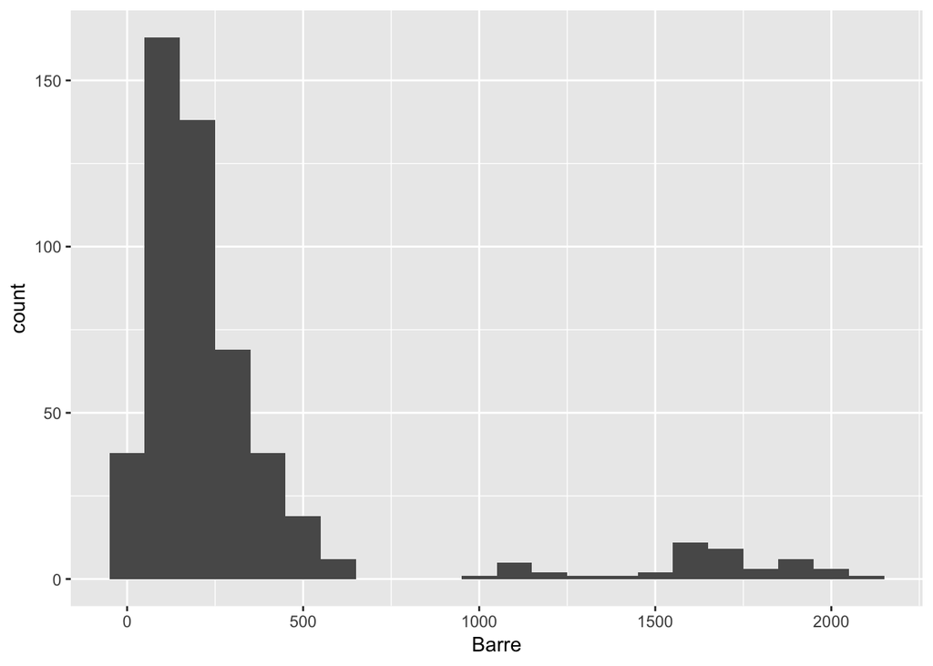

```r
ggplot(data = mutations, aes(x = Barre)) +
  geom_histogram(binwidth = 100)
```

Et complétons cet histogramme par quelques informations statistiques qui le résument :

```r
summary(mutations$Barre)
```

```
##    Min. 1st Qu.  Median    Mean 3rd Qu.    Max.
##    21.0   111.0   196.0   321.9   292.0  2056.0
```

La distribution présente une queue à droite, ce qui signifie que la majorité des observations présentent un `Barre` en dessous de la moyenne plutôt qu’au-dessus. En effet, 50% des observations sont sous la valeur de 196 alors que la moyenne se situe à 321.9. La valeur maximum se situe à 2056, qui est très éloignée de la moyenne et de la mediane.

Regardons la corrélation des variables avec la fonction pairs :

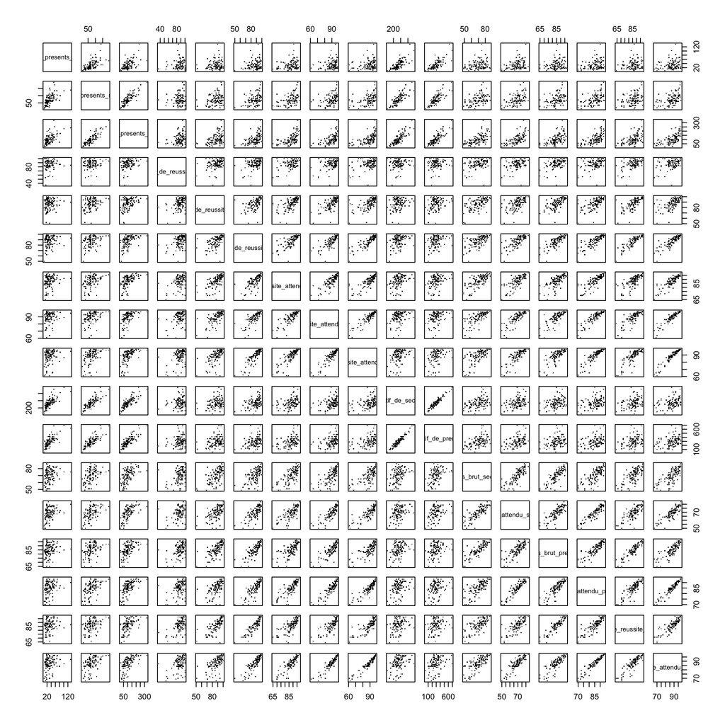

```r
pairs(mutations[,7:23], pch='.')
```

Les effectifs de seconde et de première sont très corrélés.

```r
m1 <- lm(Barre ~ effectif_presents_serie_l + effectif_presents_serie_es +
    effectif_presents_serie_s + taux_brut_de_reussite_serie_l +
    taux_brut_de_reussite_serie_es + taux_brut_de_reussite_serie_s +
    taux_reussite_attendu_serie_l + taux_reussite_attendu_serie_es +
    taux_reussite_attendu_serie_s + effectif_de_seconde + effectif_de_premiere +
    taux_acces_brut_seconde_bac + taux_acces_attendu_seconde_bac +
    taux_acces_brut_premiere_bac + taux_acces_attendu_premiere_bac +
    taux_brut_de_reussite_total_series + taux_reussite_attendu_total_series +
    departement, data = mutations)
vif(m1)

mutations_datamatrix=data.matrix(mutations)
options(max.print=1000000)
cor(mutations_datamatrix)
```

Nous avons masqué le résultat car il est beaucoup trop verbeux. Les conclusions à en tirer sont les suivantes :  
* Les effectifs sont tous corrélés entre eux.  
* Les taux brut de réussite sont corrélés aux taux de réussite attendus.  
* Les taux d’accès sont corrélés à tous les autres taux.  
* Les taux de réussite total sont corrélés aux taux de réussite brut et attendus de chaque série.

# 1. Régression linéaire

On propose d’abord un modèle linéaire gaussien. On cherche à expliquer le nombre de points nécessaire à une mutation (colonne Barre) par les caractéristiques du lycée.

## 1. Effectuer une régression linéaire bayésienne et interpréter les coefficients obtenus.

On commence avec un modèle contenant toutes les variables sauf le code établissement, la ville, l’établissement, la commune, la matière.

```r
model_1 <- lm(Barre ~ effectif_presents_serie_l + effectif_presents_serie_es +
    effectif_presents_serie_s + taux_brut_de_reussite_serie_l +
    taux_brut_de_reussite_serie_es + taux_brut_de_reussite_serie_s +
    taux_reussite_attendu_serie_l + taux_reussite_attendu_serie_es +
    taux_reussite_attendu_serie_s + effectif_de_seconde + effectif_de_premiere +
    taux_acces_brut_seconde_bac + taux_acces_attendu_seconde_bac +
    taux_acces_brut_premiere_bac + taux_acces_attendu_premiere_bac +
    taux_brut_de_reussite_total_series + taux_reussite_attendu_total_series +
    departement, data = mutations)
summary(model_1)
```

```
##
## Call:
## lm(formula = Barre ~ effectif_presents_serie_l + effectif_presents_serie_es +
##     effectif_presents_serie_s + taux_brut_de_reussite_serie_l +
##     taux_brut_de_reussite_serie_es + taux_brut_de_reussite_serie_s +
##     taux_reussite_attendu_serie_l + taux_reussite_attendu_serie_es +
##     taux_reussite_attendu_serie_s + effectif_de_seconde + effectif_de_premiere +
##     taux_acces_brut_seconde_bac + taux_acces_attendu_seconde_bac +
##     taux_acces_brut_premiere_bac + taux_acces_attendu_premiere_bac +
##     taux_brut_de_reussite_total_series + taux_reussite_attendu_total_series +
##     departement, data = mutations)
##
## Residuals:
##     Min      1Q  Median      3Q     Max
## -430.58 -205.44 -125.09  -10.97 1633.88
##
## Coefficients:
##                                      Estimate Std. Error t value Pr(>|t|)
## (Intercept)                        -718.60152  747.26926  -0.962   0.3367
## effectif_presents_serie_l             0.79074    1.63975   0.482   0.6299
## effectif_presents_serie_es            0.35687    1.24218   0.287   0.7740
## effectif_presents_serie_s            -0.09837    1.04287  -0.094   0.9249
## taux_brut_de_reussite_serie_l         2.93445    2.58912   1.133   0.2576
## taux_brut_de_reussite_serie_es        5.25808    4.30355   1.222   0.2224
## taux_brut_de_reussite_serie_s        10.06306    6.53192   1.541   0.1241
## taux_reussite_attendu_serie_l       -13.94750    6.91739  -2.016   0.0443
## taux_reussite_attendu_serie_es        4.35506    8.33904   0.522   0.6017
## taux_reussite_attendu_serie_s        -5.13959    9.74174  -0.528   0.5980
## effectif_de_seconde                   0.03974    0.62345   0.064   0.9492
## effectif_de_premiere                 -0.34390    0.71898  -0.478   0.6326
## taux_acces_brut_seconde_bac          10.93310    5.67196   1.928   0.0545
## taux_acces_attendu_seconde_bac       -7.85611    9.18007  -0.856   0.3925
## taux_acces_brut_premiere_bac        -20.28864   10.71588  -1.893   0.0589
## taux_acces_attendu_premiere_bac      34.99582   19.21108   1.822   0.0691
## taux_brut_de_reussite_total_series   -6.00074   12.95207  -0.463   0.6433
## taux_reussite_attendu_total_series   -3.58180   22.06235  -0.162   0.8711
## departement                           1.80398    3.63514   0.496   0.6199
##
## (Intercept)
## effectif_presents_serie_l
```

[output cut: 8 more lines]

```
## effectif_de_seconde
## effectif_de_premiere
## taux_acces_brut_seconde_bac        .
## taux_acces_attendu_seconde_bac
## taux_acces_brut_premiere_bac       .
## taux_acces_attendu_premiere_bac    .
## taux_brut_de_reussite_total_series
## taux_reussite_attendu_total_series
## departement
## ---
## Signif. codes:  0 '***' 0.001 '**' 0.01 '*' 0.05 '.' 0.1 ' ' 1
##
## Residual standard error: 422.7 on 497 degrees of freedom
## Multiple R-squared:  0.04115,    Adjusted R-squared:  0.006427
## F-statistic: 1.185 on 18 and 497 DF,  p-value: 0.2684
```

On réalise une inférence bayésienne à l’aide de la loi a prior g de Zellner, et on obtient a posteriori les espérances de sigma^2 et des Beta :

```r
betahat = model_1$coefficients
residuals = model_1$residuals
s2 = t(residuals)%*%residuals
X <- as.matrix(mutations[, 7:24])
X = cbind(1,X) # on ajoute une colonne de 1 pour beta_0
m = ncol(X)
n = nrow(mutations)
g = n

# espérance de sigma^2
a = n/2
b = s2/2 + 1/(2*g+2) * ((t(betahat)%*%t(X))%*%(X%*%betahat))
print(paste("Espérance de sigma^2 :", round(b/(a-1), 2)))
```

```
## [1] "Espérance de sigma^2 : 172972.1"
```

```r
# espérance des beta:
for (i in 1:m) {
  print(paste("Beta", i-1, ":", round(betahat[i]*g/(g+1), 2)))
  }
```

```
## [1] "Beta 0 : -717.21"
## [1] "Beta 1 : 0.79"
## [1] "Beta 2 : 0.36"
## [1] "Beta 3 : -0.1"
## [1] "Beta 4 : 2.93"
## [1] "Beta 5 : 5.25"
## [1] "Beta 6 : 10.04"
## [1] "Beta 7 : -13.92"
## [1] "Beta 8 : 4.35"
## [1] "Beta 9 : -5.13"
## [1] "Beta 10 : 0.04"
## [1] "Beta 11 : -0.34"
## [1] "Beta 12 : 10.91"
## [1] "Beta 13 : -7.84"
## [1] "Beta 14 : -20.25"
## [1] "Beta 15 : 34.93"
## [1] "Beta 16 : -5.99"
## [1] "Beta 17 : -3.57"
## [1] "Beta 18 : 1.8"
```

On obtient des coefficients proches de ceux obtenus avec la régression linéaire standard (ce qui était attendu).

## 2. Choisir les covariables significatives. Comparer au résultat obtenu par une analyse fréquentiste.

### Step AIC en fréquentiste

Voyons ce que donne un step AIC pour la sélection de modèle en fréquentiste :

```r
best_model <- stepAIC(model_1,  trace=FALSE)
best_model$anova
```

```
## Stepwise Model Path
## Analysis of Deviance Table
##
## Initial Model:
## Barre ~ effectif_presents_serie_l + effectif_presents_serie_es +
##     effectif_presents_serie_s + taux_brut_de_reussite_serie_l +
##     taux_brut_de_reussite_serie_es + taux_brut_de_reussite_serie_s +
##     taux_reussite_attendu_serie_l + taux_reussite_attendu_serie_es +
##     taux_reussite_attendu_serie_s + effectif_de_seconde + effectif_de_premiere +
##     taux_acces_brut_seconde_bac + taux_acces_attendu_seconde_bac +
##     taux_acces_brut_premiere_bac + taux_acces_attendu_premiere_bac +
##     taux_brut_de_reussite_total_series + taux_reussite_attendu_total_series +
##     departement
##
## Final Model:
## Barre ~ taux_reussite_attendu_serie_l + taux_acces_attendu_premiere_bac
##
##
##                                    Step Df    Deviance Resid. Df
## 1                                                            497
## 2                 - effectif_de_seconde  1    726.0447       498
## 3           - effectif_presents_serie_s  1   1502.5358       499
## 4  - taux_reussite_attendu_total_series  1   6045.1714       500
## 5          - effectif_presents_serie_es  1  14150.6304       501
## 6      - taux_reussite_attendu_serie_es  1  37764.8232       502
## 7                         - departement  1  31150.0482       503
## 8           - effectif_presents_serie_l  1  55457.4971       504
## 9  - taux_brut_de_reussite_total_series  1  80103.2470       505
## 10      - taux_reussite_attendu_serie_s  1  73327.0426       506
## 11               - effectif_de_premiere  1  76780.6521       507
## 12     - taux_acces_attendu_seconde_bac  1  76775.2088       508
## 13      - taux_brut_de_reussite_serie_l  1 221047.6824       509
## 14      - taux_brut_de_reussite_serie_s  1 267455.6391       510
## 15     - taux_brut_de_reussite_serie_es  1 178958.7930       511
## 16       - taux_acces_brut_premiere_bac  1 184758.4582       512
## 17        - taux_acces_brut_seconde_bac  1 154233.6383       513
##    Resid. Dev      AIC
## 1    88796859 6258.770
## 2    88797585 6256.774
## 3    88799088 6254.783
## 4    88805133 6252.818
## 5    88819283 6250.900
## 6    88857048 6249.119
## 7    88888198 6247.300
## 8    88943656 6245.622
## 9    89023759 6244.086
## 10   89097086 6242.511
## 11   89173867 6240.956
## 12   89250642 6239.400
## 13   89471690 6238.676
## 14   89739145 6238.216
## 15   89918104 6237.244
## 16   90102863 6236.304
## 17   90257096 6235.186
```

On obtient le modèle 2 suivant : Barre ~ taux_reussite_attendu_serie_l + taux_acces_attendu_premiere_bac

```r
model_2 <- lm(Barre ~ taux_reussite_attendu_serie_l + taux_acces_attendu_premiere_bac, data = mutations)
summary(model_2)
```

```
##
## Call:
## lm(formula = Barre ~ taux_reussite_attendu_serie_l + taux_acces_attendu_premiere_bac,
##     data = mutations)
##
## Residuals:
##     Min      1Q  Median      3Q     Max
## -387.32 -196.56 -130.83  -14.95 1696.20
##
## Coefficients:
##                                 Estimate Std. Error t value Pr(>|t|)
## (Intercept)                     -494.324    260.593  -1.897  0.05840 .
## taux_reussite_attendu_serie_l     -7.882      4.360  -1.808  0.07124 .
## taux_acces_attendu_premiere_bac   17.833      5.407   3.298  0.00104 **
## ---
## Signif. codes:  0 '***' 0.001 '**' 0.01 '*' 0.05 '.' 0.1 ' ' 1
##
## Residual standard error: 419.5 on 513 degrees of freedom
## Multiple R-squared:  0.02539,    Adjusted R-squared:  0.02159
## F-statistic: 6.681 on 2 and 513 DF,  p-value: 0.001366
```

### Step BIC en analyse bayésienne

Nous allons réaliser un step BIC (Bayesian Information Criterion). Plus le BIC est petit, plus le modèle est à privilégier. En effet le BIC correspond à $BIC = -2ln(likelihood) + (p+1)ln(n)$. Plus on maximise la vraisemblance et plus on minimise le BIC, avec une pénalité sur le nombre de paramètres : n étant le nombre d’observations et p le nombre de coefficients avec l’intercept.

Pour faire un step BIC avec R, il est nécessaire d’indiquer k=log(n) dans la fonction stepAIC, qui devient alors un stepBIC.

```r
n <- nrow(mutations)
best_model_B <- stepAIC(model_1, k=log(n), trace=FALSE)
best_model_B$anova
```

```
## Stepwise Model Path
## Analysis of Deviance Table
##
## Initial Model:
## Barre ~ effectif_presents_serie_l + effectif_presents_serie_es +
##     effectif_presents_serie_s + taux_brut_de_reussite_serie_l +
##     taux_brut_de_reussite_serie_es + taux_brut_de_reussite_serie_s +
##     taux_reussite_attendu_serie_l + taux_reussite_attendu_serie_es +
##     taux_reussite_attendu_serie_s + effectif_de_seconde + effectif_de_premiere +
##     taux_acces_brut_seconde_bac + taux_acces_attendu_seconde_bac +
##     taux_acces_brut_premiere_bac + taux_acces_attendu_premiere_bac +
##     taux_brut_de_reussite_total_series + taux_reussite_attendu_total_series +
##     departement
##
## Final Model:
## Barre ~ taux_acces_attendu_premiere_bac
##
##
##                                    Step Df    Deviance Resid. Df
## 1                                                            497
## 2                 - effectif_de_seconde  1    726.0447       498
## 3           - effectif_presents_serie_s  1   1502.5358       499
## 4  - taux_reussite_attendu_total_series  1   6045.1714       500
## 5          - effectif_presents_serie_es  1  14150.6304       501
## 6      - taux_reussite_attendu_serie_es  1  37764.8232       502
## 7                         - departement  1  31150.0482       503
## 8           - effectif_presents_serie_l  1  55457.4971       504
## 9  - taux_brut_de_reussite_total_series  1  80103.2470       505
## 10      - taux_reussite_attendu_serie_s  1  73327.0426       506
## 11               - effectif_de_premiere  1  76780.6521       507
## 12     - taux_acces_attendu_seconde_bac  1  76775.2088       508
## 13      - taux_brut_de_reussite_serie_l  1 221047.6824       509
## 14      - taux_brut_de_reussite_serie_s  1 267455.6391       510
## 15     - taux_brut_de_reussite_serie_es  1 178958.7930       511
## 16       - taux_acces_brut_premiere_bac  1 184758.4582       512
## 17        - taux_acces_brut_seconde_bac  1 154233.6383       513
## 18      - taux_reussite_attendu_serie_l  1 574942.0973       514
##    Resid. Dev      AIC
## 1    88796859 6339.446
## 2    88797585 6333.204
## 3    88799088 6326.966
## 4    88805133 6320.755
## 5    88819283 6314.592
## 6    88857048 6308.565
## 7    88888198 6302.500
## 8    88943656 6296.575
## 9    89023759 6290.794
## 10   89097086 6284.972
## 11   89173867 6279.171
## 12   89250642 6273.369
## 13   89471690 6268.399
## 14   89739145 6263.693
## 15   89918104 6258.475
## 16   90102863 6253.288
## 17   90257096 6247.924
## 18   90832038 6244.955
```

On obtient alors un modèle très simple : Barre ~ taux_acces_attendu_premiere_bac

```r
model_3 <- lm(Barre ~ taux_acces_attendu_premiere_bac, data = mutations)
summary(model_3)
```

```
##
## Call:
## lm(formula = Barre ~ taux_acces_attendu_premiere_bac, data = mutations)
##
## Residuals:
##     Min      1Q  Median      3Q     Max
## -380.36 -199.53 -129.26  -25.62 1686.87
##
## Coefficients:
##                                 Estimate Std. Error t value Pr(>|t|)
## (Intercept)                     -503.790    261.114  -1.929  0.05423 .
## taux_acces_attendu_premiere_bac    9.808      3.094   3.170  0.00161 **
## ---
## Signif. codes:  0 '***' 0.001 '**' 0.01 '*' 0.05 '.' 0.1 ' ' 1
##
## Residual standard error: 420.4 on 514 degrees of freedom
## Multiple R-squared:  0.01918,    Adjusted R-squared:  0.01727
## F-statistic: 10.05 on 1 and 514 DF,  p-value: 0.001614
```

En analyse bayésienne nous gardons donc la variable `taux_acces_attendu_premiere_bac` comme pour l’analyse fréquentiste, mais nous ne conservons pas la variable `taux_reussite_attendu_serie_l`

### Sélection de modèle en calculant la probabilité postérieure des différents modèles

On va également utiliser la librairie BAS pour calculer les probabilités postérieures des différents modèles. Pour la prior sur les coefficients, on utilise la loi informative de Zellner g-prior. On utilise ensuite modelprior = uniform() pour assigner une probabilité égale p(Mm) à chaque modèle.

```r
# Fit le modèle en utilisant la régression linéaire Bayésienne
bma_Barre <- bas.lm(Barre ~ effectif_presents_serie_l + effectif_presents_serie_es +
    effectif_presents_serie_s + taux_brut_de_reussite_serie_l +
    taux_brut_de_reussite_serie_es + taux_brut_de_reussite_serie_s +
    taux_reussite_attendu_serie_l + taux_reussite_attendu_serie_es +
    taux_reussite_attendu_serie_s + effectif_de_seconde + effectif_de_premiere +
    taux_acces_brut_seconde_bac + taux_acces_attendu_seconde_bac +
    taux_acces_brut_premiere_bac + taux_acces_attendu_premiere_bac +
    taux_brut_de_reussite_total_series + taux_reussite_attendu_total_series +
    departement, data = mutations,
    prior = "g-prior", alpha = n,
    modelprior = uniform())

# Affiche la probabilité marginale postérieure d'inclusion de chaque variable
bma_Barre
```

```
##
## Call:
## bas.lm(formula = Barre ~ effectif_presents_serie_l + effectif_presents_serie_es +
##     effectif_presents_serie_s + taux_brut_de_reussite_serie_l +
##     taux_brut_de_reussite_serie_es + taux_brut_de_reussite_serie_s +
##     taux_reussite_attendu_serie_l + taux_reussite_attendu_serie_es +
##     taux_reussite_attendu_serie_s + effectif_de_seconde + effectif_de_premiere +
##     taux_acces_brut_seconde_bac + taux_acces_attendu_seconde_bac +
##     taux_acces_brut_premiere_bac + taux_acces_attendu_premiere_bac +
##     taux_brut_de_reussite_total_series + taux_reussite_attendu_total_series +
##     departement, data = mutations, prior = "g-prior", alpha = n,
##     modelprior = uniform())
##
##
##  Marginal Posterior Inclusion Probabilities:
##                          Intercept           effectif_presents_serie_l
##                            1.00000                             0.04418
##         effectif_presents_serie_es           effectif_presents_serie_s
##                            0.04475                             0.04972
##      taux_brut_de_reussite_serie_l      taux_brut_de_reussite_serie_es
##                            0.05019                             0.08321
##      taux_brut_de_reussite_serie_s       taux_reussite_attendu_serie_l
##                            0.07790                             0.12025
##     taux_reussite_attendu_serie_es       taux_reussite_attendu_serie_s
##                            0.11704                             0.10269
##                effectif_de_seconde                effectif_de_premiere
##                            0.04404                             0.04449
##        taux_acces_brut_seconde_bac      taux_acces_attendu_seconde_bac
##                            0.09098                             0.19215
##       taux_acces_brut_premiere_bac     taux_acces_attendu_premiere_bac
##                            0.07754                             0.31882
## taux_brut_de_reussite_total_series  taux_reussite_attendu_total_series
##                            0.11486                             0.11585
##                        departement
##                            0.04705
```

```r
# Les 5 modèles les plus probables
summary(bma_Barre)
```

```
##                                    P(B != 0 | Y)  model 1  model 2
## Intercept                             1.00000000 1.000000 1.000000
## effectif_presents_serie_l             0.04417671 0.000000 0.000000
## effectif_presents_serie_es            0.04474677 0.000000 0.000000
## effectif_presents_serie_s             0.04972273 0.000000 0.000000
## taux_brut_de_reussite_serie_l         0.05018712 0.000000 0.000000
## taux_brut_de_reussite_serie_es        0.08320684 0.000000 0.000000
## taux_brut_de_reussite_serie_s         0.07789784 0.000000 0.000000
## taux_reussite_attendu_serie_l         0.12025461 0.000000 0.000000
## taux_reussite_attendu_serie_es        0.11704195 0.000000 0.000000
## taux_reussite_attendu_serie_s         0.10269267 0.000000 0.000000
## effectif_de_seconde                   0.04403972 0.000000 0.000000
## effectif_de_premiere                  0.04448697 0.000000 0.000000
## taux_acces_brut_seconde_bac           0.09097812 0.000000 0.000000
## taux_acces_attendu_seconde_bac        0.19215280 0.000000 1.000000
## taux_acces_brut_premiere_bac          0.07753826 0.000000 0.000000
## taux_acces_attendu_premiere_bac       0.31881686 1.000000 0.000000
## taux_brut_de_reussite_total_series    0.11486306 0.000000 0.000000
## taux_reussite_attendu_total_series    0.11584968 0.000000 0.000000
## departement                           0.04704963 0.000000 0.000000
## BF                                            NA 1.000000 0.658676
## PostProbs                                     NA 0.119300 0.078600
## R2                                            NA 0.019200 0.017600
## dim                                           NA 2.000000 2.000000
## logmarg                                       NA 1.852539 1.435015
##                                      model 3   model 4   model 5
## Intercept                          1.0000000 1.0000000 1.0000000
## effectif_presents_serie_l          0.0000000 0.0000000 0.0000000
## effectif_presents_serie_es         0.0000000 0.0000000 0.0000000
## effectif_presents_serie_s          0.0000000 0.0000000 0.0000000
## taux_brut_de_reussite_serie_l      0.0000000 0.0000000 0.0000000
## taux_brut_de_reussite_serie_es     0.0000000 0.0000000 0.0000000
## taux_brut_de_reussite_serie_s      0.0000000 0.0000000 0.0000000
## taux_reussite_attendu_serie_l      0.0000000 0.0000000 0.0000000
## taux_reussite_attendu_serie_es     0.0000000 1.0000000 0.0000000
## taux_reussite_attendu_serie_s      0.0000000 0.0000000 1.0000000
## effectif_de_seconde                0.0000000 0.0000000 0.0000000
## effectif_de_premiere               0.0000000 0.0000000 0.0000000
## taux_acces_brut_seconde_bac        0.0000000 0.0000000 0.0000000
## taux_acces_attendu_seconde_bac     0.0000000 0.0000000 0.0000000
## taux_acces_brut_premiere_bac       0.0000000 0.0000000 0.0000000
## taux_acces_attendu_premiere_bac    0.0000000 0.0000000 0.0000000
## taux_brut_de_reussite_total_series 1.0000000 0.0000000 0.0000000
## taux_reussite_attendu_total_series 0.0000000 0.0000000 0.0000000
## departement                        0.0000000 0.0000000 0.0000000
## BF                                 0.3649756 0.3485698 0.2969411
## PostProbs                          0.0435000 0.0416000 0.0354000
## R2                                 0.0153000 0.0151000 0.0145000
## dim                                2.0000000 2.0000000 2.0000000
## logmarg                            0.8446142 0.7986220 0.6383173
```

On peut également visualiser les différents modèles pour les comparer :

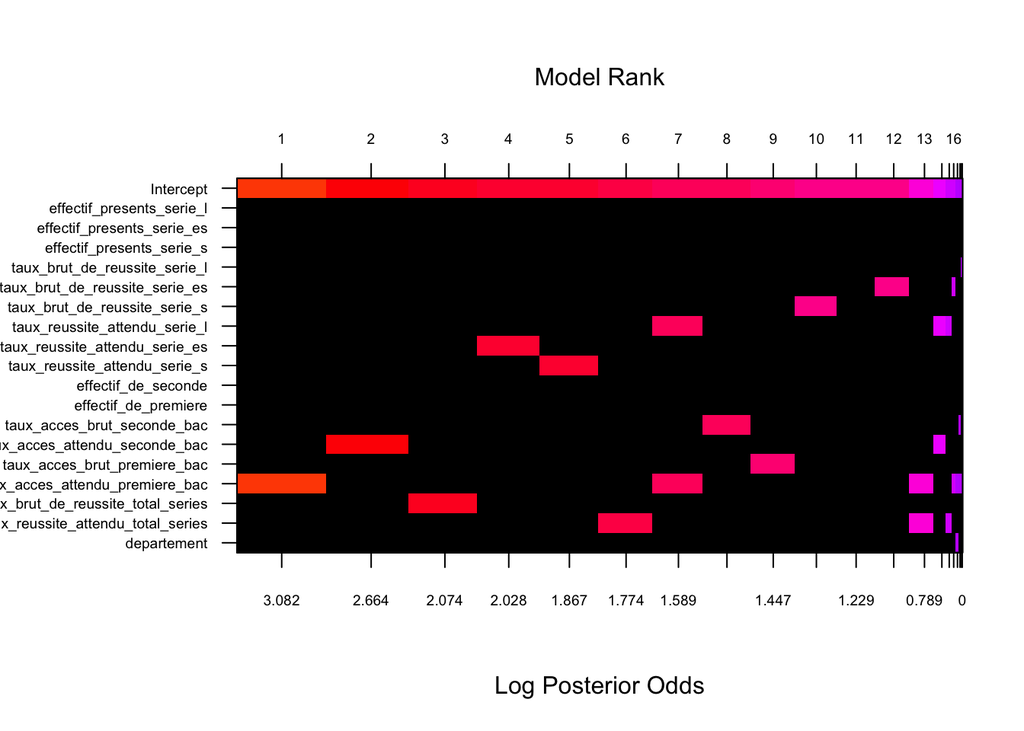

```r
image(bma_Barre, rotate = F, cex.axis = 0.6)
title(font.main=2)
```

Les modèles sont rangés selon le log du posterior odd sur le modèle contenant seulement l’intercept (et ce log correspond au log du Bayes Factor).

Etant donné qu’on a les probabilités postérieures de chaque modèle, on peut calculer le BMA - Bayesian Model Average, qui est une moyenne pondérée des différents modèles selon leur probabilité.  
Voici les coefficients selon le BMA :

```r
coef_Barre <- coefficients(bma_Barre)
coef_Barre
```

```
##
##  Marginal Posterior Summaries of Coefficients:
##
##  Using  BMA
##
##  Based on the top  262144 models
##                                     post mean   post SD     post p(B != 0)
## Intercept                           321.915504   18.541160    1.000000
## effectif_presents_serie_l             0.009632    0.220417    0.044177
## effectif_presents_serie_es            0.001573    0.150234    0.044747
## effectif_presents_serie_s             0.007956    0.123455    0.049723
## taux_brut_de_reussite_serie_l         0.048434    0.470407    0.050187
## taux_brut_de_reussite_serie_es        0.243327    1.109243    0.083207
## taux_brut_de_reussite_serie_s         0.237423    1.259487    0.077898
## taux_reussite_attendu_serie_l        -0.794949    2.816678    0.120255
## taux_reussite_attendu_serie_es        0.585025    2.238766    0.117042
## taux_reussite_attendu_serie_s         0.403572    1.828661    0.102693
## effectif_de_seconde                  -0.001229    0.041897    0.044040
## effectif_de_premiere                 -0.001645    0.046090    0.044487
## taux_acces_brut_seconde_bac           0.328783    1.419720    0.090978
## taux_acces_attendu_seconde_bac        1.386121    3.421147    0.192153
## taux_acces_brut_premiere_bac          0.270053    1.799192    0.077538
## taux_acces_attendu_premiere_bac       3.930614    7.162803    0.318817
## taux_brut_de_reussite_total_series    0.634772    2.329279    0.114863
## taux_reussite_attendu_total_series    0.194730    3.692020    0.115850
## departement                           0.064188    0.741223    0.047050
```

On peut aussi voir la distribution postérieure de ces coefficients sous le modèle BMA (et remarquer que certains ont 0 bien au milieu de leur intervalle de crédibilité) :

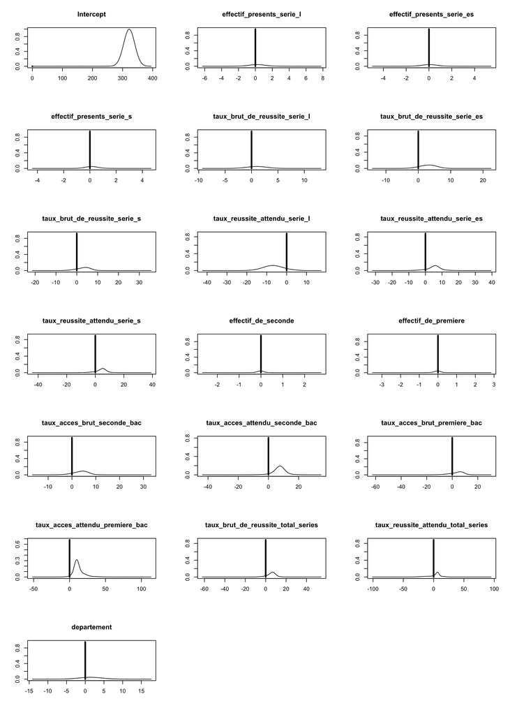

```r
# on plot les distributions de ces coefficients
par(mfrow = c(7,3))
plot(coef_Barre, ask = FALSE)
```

Nous pouvons également fournir les intervalles de crédibilité à 95% pour ces coefficients :

```r
confint(coef_Barre)
```

```
##                                             2.5%        97.5%
## Intercept                          286.387317980 358.49178632
## effectif_presents_serie_l            0.000000000   0.00000000
## effectif_presents_serie_es           0.000000000   0.00000000
## effectif_presents_serie_s           -0.009398392   0.00000000
## taux_brut_de_reussite_serie_l       -0.282095703   0.09350587
## taux_brut_de_reussite_serie_es      -0.019217415   3.59193905
## taux_brut_de_reussite_serie_s        0.000000000   3.83726647
## taux_reussite_attendu_serie_l       -8.854694093   0.01809166
## taux_reussite_attendu_serie_es       0.000000000   7.10699363
## taux_reussite_attendu_serie_s       -0.015970386   5.99669134
## effectif_de_seconde                  0.000000000   0.00000000
## effectif_de_premiere                 0.000000000   0.00000000
## taux_acces_brut_seconde_bac          0.000000000   4.53969449
## taux_acces_attendu_seconde_bac       0.000000000  10.24635820
## taux_acces_brut_premiere_bac         0.000000000   5.41813454
## taux_acces_attendu_premiere_bac      0.000000000  18.76319983
## taux_brut_de_reussite_total_series  -0.010158358   7.63774638
## taux_reussite_attendu_total_series  -0.067111654   9.60765554
## departement                          0.000000000   0.00000000
##                                             beta
## Intercept                          321.915503876
## effectif_presents_serie_l            0.009632313
## effectif_presents_serie_es           0.001573358
## effectif_presents_serie_s            0.007956123
## taux_brut_de_reussite_serie_l        0.048434432
## taux_brut_de_reussite_serie_es       0.243327123
## taux_brut_de_reussite_serie_s        0.237423454
## taux_reussite_attendu_serie_l       -0.794948647
## taux_reussite_attendu_serie_es       0.585025172
## taux_reussite_attendu_serie_s        0.403572168
## effectif_de_seconde                 -0.001228669
## effectif_de_premiere                -0.001644569
## taux_acces_brut_seconde_bac          0.328782594
## taux_acces_attendu_seconde_bac       1.386121340
## taux_acces_brut_premiere_bac         0.270053023
## taux_acces_attendu_premiere_bac      3.930614049
## taux_brut_de_reussite_total_series   0.634771960
## taux_reussite_attendu_total_series   0.194730383
## departement                          0.064187599
## attr(,"Probability")
## [1] 0.95
## attr(,"class")
## [1] "confint.bas"
```

### Premières conclusions

Il est intéressant de constater que la méthode fréquentiste et la méthode bayésienne ne donnent pas les mêmes résultats. Les deux méthodes sont d’accord pour affirmer que la variable `taux_acces_attendu_premiere_bac` a une influence sur la variable `Barre`. En revanche, là où la méthode fréquentiste va préconiser d’intégrer également la variable `taux_reussite_attendu_serie_l` dans le modèle, la méthode bayésienne aura plutôt tendance à ne garder que la premièree variable ou alors à mettre du poids également sur les variables `taux_acces_attendu_seconde_bac` et `taux_brut_de_reussite_total_series`. Il peut être intéressant de regarder ce qui se passe par Matière car un professeur de Maths sera peut-être moins intéressé par le `taux_reussite_attendu_serie_l`.

## 3. On se concentre maintenant uniquement sur les mutations en mathématiques et en anglais.

*Répéter l’analyse pour chacune de ces deux catégories. Que penser de l’hypothèse que les covariables agissent de la même manière dans ces deux disciplines ?*

On crée des sous-jeux de données pour chaque Matière :

```r
mutations_Maths <- mutations %>%
  filter(Matiere == 'MATHS')

mutations_Anglais <- mutations %>%
  filter(Matiere == 'ANGLAIS')
```

### Maths

Réalisons d’abord une régression linéaire pour les Mathématiques, avec l’ensemble des variables excepté le code établissement, l’établissement, la ville, la commune :

```r
Maths_model_1 <- lm(Barre ~ effectif_presents_serie_l + effectif_presents_serie_es +
    effectif_presents_serie_s + taux_brut_de_reussite_serie_l +
    taux_brut_de_reussite_serie_es + taux_brut_de_reussite_serie_s +
    taux_reussite_attendu_serie_l + taux_reussite_attendu_serie_es +
    taux_reussite_attendu_serie_s + effectif_de_seconde + effectif_de_premiere +
    taux_acces_brut_seconde_bac + taux_acces_attendu_seconde_bac +
    taux_acces_brut_premiere_bac + taux_acces_attendu_premiere_bac +
    taux_brut_de_reussite_total_series + taux_reussite_attendu_total_series +
    departement, data = mutations_Maths)
summary(Maths_model_1)
```

```
##
## Call:
## lm(formula = Barre ~ effectif_presents_serie_l + effectif_presents_serie_es +
##     effectif_presents_serie_s + taux_brut_de_reussite_serie_l +
##     taux_brut_de_reussite_serie_es + taux_brut_de_reussite_serie_s +
##     taux_reussite_attendu_serie_l + taux_reussite_attendu_serie_es +
##     taux_reussite_attendu_serie_s + effectif_de_seconde + effectif_de_premiere +
##     taux_acces_brut_seconde_bac + taux_acces_attendu_seconde_bac +
##     taux_acces_brut_premiere_bac + taux_acces_attendu_premiere_bac +
##     taux_brut_de_reussite_total_series + taux_reussite_attendu_total_series +
##     departement, data = mutations_Maths)
##
## Residuals:
##     Min      1Q  Median      3Q     Max
## -158.34  -71.25  -16.19   73.22  285.45
##
## Coefficients:
##                                     Estimate Std. Error t value Pr(>|t|)
## (Intercept)                        -222.6752   620.6736  -0.359   0.7217
## effectif_presents_serie_l             0.3071     1.2595   0.244   0.8086
## effectif_presents_serie_es           -0.2926     0.9742  -0.300   0.7655
## effectif_presents_serie_s             1.0749     0.8593   1.251   0.2182
## taux_brut_de_reussite_serie_l        -4.1104     2.2124  -1.858   0.0706 .
## taux_brut_de_reussite_serie_es        7.9225     4.2785   1.852   0.0715 .
## taux_brut_de_reussite_serie_s         2.0319     5.6659   0.359   0.7218
## taux_reussite_attendu_serie_l        -3.4805     5.7418  -0.606   0.5478
## taux_reussite_attendu_serie_es       -5.5958     7.2505  -0.772   0.4448
## taux_reussite_attendu_serie_s        -3.1439     8.5248  -0.369   0.7142
## effectif_de_seconde                   0.8185     0.5266   1.554   0.1280
## effectif_de_premiere                 -1.3987     0.6352  -2.202   0.0335 *
## taux_acces_brut_seconde_bac          12.7858     6.2497   2.046   0.0474 *
## taux_acces_attendu_seconde_bac       -9.5586     7.3500  -1.300   0.2009
## taux_acces_brut_premiere_bac        -11.9159    10.5759  -1.127   0.2666
## taux_acces_attendu_premiere_bac       5.2983    15.0654   0.352   0.7269
## taux_brut_de_reussite_total_series    0.8993    11.0960   0.081   0.9358
## taux_reussite_attendu_total_series   12.1479    17.8442   0.681   0.4999
## departement                           2.2111     2.9018   0.762   0.4506
## ---
## Signif. codes:  0 '***' 0.001 '**' 0.01 '*' 0.05 '.' 0.1 ' ' 1
##
## Residual standard error: 117 on 40 degrees of freedom
## Multiple R-squared:  0.3915, Adjusted R-squared:  0.1176
## F-statistic:  1.43 on 18 and 40 DF,  p-value: 0.1707
```

Sélectionnons le meilleur modèle avec la méthode fréquentiste AIC :

```r
best_model_maths <- stepAIC(Maths_model_1, trace=FALSE)
best_model_maths$anova
```

```
## Stepwise Model Path
## Analysis of Deviance Table
##
## Initial Model:
## Barre ~ effectif_presents_serie_l + effectif_presents_serie_es +
##     effectif_presents_serie_s + taux_brut_de_reussite_serie_l +
##     taux_brut_de_reussite_serie_es + taux_brut_de_reussite_serie_s +
##     taux_reussite_attendu_serie_l + taux_reussite_attendu_serie_es +
##     taux_reussite_attendu_serie_s + effectif_de_seconde + effectif_de_premiere +
##     taux_acces_brut_seconde_bac + taux_acces_attendu_seconde_bac +
##     taux_acces_brut_premiere_bac + taux_acces_attendu_premiere_bac +
##     taux_brut_de_reussite_total_series + taux_reussite_attendu_total_series +
##     departement
##
## Final Model:
## Barre ~ effectif_presents_serie_s + taux_brut_de_reussite_serie_l +
##     taux_brut_de_reussite_serie_es + effectif_de_seconde + effectif_de_premiere +
##     taux_acces_brut_seconde_bac
##
##
##                                    Step Df    Deviance Resid. Df
## 1                                                             40
## 2  - taux_brut_de_reussite_total_series  1    89.98197        41
## 3           - effectif_presents_serie_l  1   796.73144        42
## 4          - effectif_presents_serie_es  1  1113.91317        43
## 5     - taux_acces_attendu_premiere_bac  1  2291.92291        44
## 6       - taux_reussite_attendu_serie_s  1  2909.57985        45
## 7       - taux_brut_de_reussite_serie_s  1  1915.61738        46
## 8       - taux_reussite_attendu_serie_l  1  5374.86023        47
## 9        - taux_acces_brut_premiere_bac  1 10863.97132        48
## 10     - taux_reussite_attendu_serie_es  1  7908.25759        49
## 11 - taux_reussite_attendu_total_series  1  3633.43811        50
## 12     - taux_acces_attendu_seconde_bac  1 11275.64993        51
## 13                        - departement  1 12445.21580        52
##    Resid. Dev      AIC
## 1    547988.4 577.0518
## 2    548078.4 575.0615
## 3    548875.1 573.1472
## 4    549989.0 571.2669
## 5    552280.9 569.5122
## 6    555190.5 567.8222
## 7    557106.1 566.0254
## 8    562481.0 564.5919
## 9    573345.0 563.7206
## 10   581253.2 562.5289
## 11   584886.7 560.8965
## 12   596162.3 560.0231
## 13   608607.5 559.2421
```

On obtient le modèle suivant : Barre ~ effectif_presents_serie_s + taux_brut_de_reussite_serie_l + taux_brut_de_reussite_serie_es + effectif_de_seconde + effectif_de_premiere + taux_acces_brut_seconde_bac

```r
Maths_model_2  = lm(Barre ~ effectif_presents_serie_s + taux_brut_de_reussite_serie_l +
    taux_brut_de_reussite_serie_es + effectif_de_seconde + effectif_de_premiere +
    taux_acces_brut_seconde_bac, data = mutations_Maths)
summary(Maths_model_2)
```

```
##
## Call:
## lm(formula = Barre ~ effectif_presents_serie_s + taux_brut_de_reussite_serie_l +
##     taux_brut_de_reussite_serie_es + effectif_de_seconde + effectif_de_premiere +
##     taux_acces_brut_seconde_bac, data = mutations_Maths)
##
## Residuals:
##     Min      1Q  Median      3Q     Max
## -222.62  -73.59  -20.98   54.23  292.99
##
## Coefficients:
##                                Estimate Std. Error t value Pr(>|t|)
## (Intercept)                    -77.4081   182.6176  -0.424   0.6734
## effectif_presents_serie_s        0.7892     0.5009   1.575   0.1212
## taux_brut_de_reussite_serie_l   -3.9693     1.5624  -2.541   0.0141 *
## taux_brut_de_reussite_serie_es   3.8648     2.2119   1.747   0.0865 .
## effectif_de_seconde              0.6536     0.3883   1.683   0.0983 .
## effectif_de_premiere            -1.1044     0.4286  -2.576   0.0129 *
## taux_acces_brut_seconde_bac      4.2086     2.6145   1.610   0.1135
## ---
## Signif. codes:  0 '***' 0.001 '**' 0.01 '*' 0.05 '.' 0.1 ' ' 1
##
## Residual standard error: 108.2 on 52 degrees of freedom
## Multiple R-squared:  0.3242, Adjusted R-squared:  0.2462
## F-statistic: 4.157 on 6 and 52 DF,  p-value: 0.001744
```

Effectuons maintenant le choix de modèle par BIC :

```r
n <- nrow(mutations_Maths)
best_model_maths_B <- stepAIC(Maths_model_1, k=log(n), trace=FALSE)
best_model_maths_B$anova
```

```
## Stepwise Model Path
## Analysis of Deviance Table
##
## Initial Model:
## Barre ~ effectif_presents_serie_l + effectif_presents_serie_es +
##     effectif_presents_serie_s + taux_brut_de_reussite_serie_l +
##     taux_brut_de_reussite_serie_es + taux_brut_de_reussite_serie_s +
##     taux_reussite_attendu_serie_l + taux_reussite_attendu_serie_es +
##     taux_reussite_attendu_serie_s + effectif_de_seconde + effectif_de_premiere +
##     taux_acces_brut_seconde_bac + taux_acces_attendu_seconde_bac +
##     taux_acces_brut_premiere_bac + taux_acces_attendu_premiere_bac +
##     taux_brut_de_reussite_total_series + taux_reussite_attendu_total_series +
##     departement
##
## Final Model:
## Barre ~ taux_brut_de_reussite_serie_es
##
##
##                                    Step Df    Deviance Resid. Df
## 1                                                             40
## 2  - taux_brut_de_reussite_total_series  1    89.98197        41
## 3           - effectif_presents_serie_l  1   796.73144        42
## 4          - effectif_presents_serie_es  1  1113.91317        43
## 5     - taux_acces_attendu_premiere_bac  1  2291.92291        44
## 6       - taux_reussite_attendu_serie_s  1  2909.57985        45
## 7       - taux_brut_de_reussite_serie_s  1  1915.61738        46
## 8       - taux_reussite_attendu_serie_l  1  5374.86023        47
## 9        - taux_acces_brut_premiere_bac  1 10863.97132        48
## 10     - taux_reussite_attendu_serie_es  1  7908.25759        49
## 11 - taux_reussite_attendu_total_series  1  3633.43811        50
## 12     - taux_acces_attendu_seconde_bac  1 11275.64993        51
## 13                        - departement  1 12445.21580        52
## 14          - effectif_presents_serie_s  1 29048.84246        53
## 15        - taux_acces_brut_seconde_bac  1 38956.07456        54
## 16               - effectif_de_premiere  1 37256.65855        55
## 17                - effectif_de_seconde  1   884.92080        56
## 18      - taux_brut_de_reussite_serie_l  1 47201.32431        57
##    Resid. Dev      AIC
## 1    547988.4 616.5251
## 2    548078.4 612.4572
## 3    548875.1 608.4654
## 4    549989.0 604.5075
## 5    552280.9 600.6753
## 6    555190.5 596.9077
## 7    557106.1 593.0334
## 8    562481.0 589.5224
## 9    573345.0 586.5735
## 10   581253.2 583.3042
## 11   584886.7 579.5944
## 12   596162.3 576.6434
## 13   608607.5 573.7849
## 14   637656.4 572.4582
## 15   676612.5 571.8794
## 16   713869.1 570.9643
## 17   714754.0 566.9598
## 18   761955.4 566.6553
```

On obtient un modèle plus simple qui ne dépend que de la variable `taux_brut_de_reussite_serie_es`.

```r
Maths_model_3 = lm(Barre ~ taux_brut_de_reussite_serie_es, data = mutations_Maths)
summary(Maths_model_3)
```

```
##
## Call:
## lm(formula = Barre ~ taux_brut_de_reussite_serie_es, data = mutations_Maths)
##
## Residuals:
##     Min      1Q  Median      3Q     Max
## -145.97  -80.44  -34.60   60.41  375.63
##
## Coefficients:
##                                Estimate Std. Error t value Pr(>|t|)
## (Intercept)                    -286.357    148.068  -1.934  0.05809 .
## taux_brut_de_reussite_serie_es    5.433      1.688   3.220  0.00212 **
## ---
## Signif. codes:  0 '***' 0.001 '**' 0.01 '*' 0.05 '.' 0.1 ' ' 1
##
## Residual standard error: 115.6 on 57 degrees of freedom
## Multiple R-squared:  0.1539, Adjusted R-squared:  0.139
## F-statistic: 10.37 on 1 and 57 DF,  p-value: 0.00212
```

Calculons maintenant les probabiltiés postérieures des différents modèles avec la libraire BAS :

```r
# Fit le modèle en utilisant la régression linéaire Bayésienne
Maths_bma_Barre <- bas.lm(Barre ~ effectif_presents_serie_l + effectif_presents_serie_es +
    effectif_presents_serie_s + taux_brut_de_reussite_serie_l +
    taux_brut_de_reussite_serie_es + taux_brut_de_reussite_serie_s +
    taux_reussite_attendu_serie_l + taux_reussite_attendu_serie_es +
    taux_reussite_attendu_serie_s + effectif_de_seconde + effectif_de_premiere +
    taux_acces_brut_seconde_bac + taux_acces_attendu_seconde_bac +
    taux_acces_brut_premiere_bac + taux_acces_attendu_premiere_bac +
    taux_brut_de_reussite_total_series + taux_reussite_attendu_total_series +
    departement, data = mutations_Maths,
    prior = "g-prior", alpha = n,
    modelprior = uniform())

# Affiche la probabilité marginale postérieure d'inclusion de chaque variable
Maths_bma_Barre
```

```
##
## Call:
## bas.lm(formula = Barre ~ effectif_presents_serie_l + effectif_presents_serie_es +
##     effectif_presents_serie_s + taux_brut_de_reussite_serie_l +
##     taux_brut_de_reussite_serie_es + taux_brut_de_reussite_serie_s +
##     taux_reussite_attendu_serie_l + taux_reussite_attendu_serie_es +
##     taux_reussite_attendu_serie_s + effectif_de_seconde + effectif_de_premiere +
##     taux_acces_brut_seconde_bac + taux_acces_attendu_seconde_bac +
##     taux_acces_brut_premiere_bac + taux_acces_attendu_premiere_bac +
##     taux_brut_de_reussite_total_series + taux_reussite_attendu_total_series +
##     departement, data = mutations_Maths, prior = "g-prior", alpha = n,
##     modelprior = uniform())
##
##
##  Marginal Posterior Inclusion Probabilities:
##                          Intercept           effectif_presents_serie_l
##                             1.0000                              0.1282
##         effectif_presents_serie_es           effectif_presents_serie_s
##                             0.1335                              0.2241
##      taux_brut_de_reussite_serie_l      taux_brut_de_reussite_serie_es
##                             0.5421                              0.5510
##      taux_brut_de_reussite_serie_s       taux_reussite_attendu_serie_l
##                             0.1376                              0.1307
##     taux_reussite_attendu_serie_es       taux_reussite_attendu_serie_s
##                             0.1419                              0.1529
##                effectif_de_seconde                effectif_de_premiere
##                             0.1715                              0.2334
##        taux_acces_brut_seconde_bac      taux_acces_attendu_seconde_bac
##                             0.1637                              0.1430
##       taux_acces_brut_premiere_bac     taux_acces_attendu_premiere_bac
##                             0.2340                              0.2604
## taux_brut_de_reussite_total_series  taux_reussite_attendu_total_series
##                             0.1849                              0.1562
##                        departement
##                             0.1334
```

```r
# Les 5 modèles les plus probables
summary(Maths_bma_Barre)
```

```
##                                    P(B != 0 | Y)  model 1   model 2
## Intercept                              1.0000000 1.000000 1.0000000
## effectif_presents_serie_l              0.1281849 0.000000 0.0000000
## effectif_presents_serie_es             0.1335491 0.000000 0.0000000
## effectif_presents_serie_s              0.2241242 0.000000 0.0000000
## taux_brut_de_reussite_serie_l          0.5421427 0.000000 1.0000000
## taux_brut_de_reussite_serie_es         0.5509595 1.000000 1.0000000
## taux_brut_de_reussite_serie_s          0.1375758 0.000000 0.0000000
## taux_reussite_attendu_serie_l          0.1307110 0.000000 0.0000000
## taux_reussite_attendu_serie_es         0.1418931 0.000000 0.0000000
## taux_reussite_attendu_serie_s          0.1528725 0.000000 0.0000000
## effectif_de_seconde                    0.1714706 0.000000 0.0000000
## effectif_de_premiere                   0.2334199 0.000000 0.0000000
## taux_acces_brut_seconde_bac            0.1637347 0.000000 0.0000000
## taux_acces_attendu_seconde_bac         0.1430337 0.000000 0.0000000
## taux_acces_brut_premiere_bac           0.2340268 0.000000 0.0000000
## taux_acces_attendu_premiere_bac        0.2604481 0.000000 0.0000000
## taux_brut_de_reussite_total_series     0.1848808 0.000000 0.0000000
## taux_reussite_attendu_total_series     0.1561592 0.000000 0.0000000
## departement                            0.1333798 0.000000 0.0000000
## BF                                            NA 1.000000 0.7943572
## PostProbs                                     NA 0.022700 0.0180000
## R2                                            NA 0.153900 0.2063000
## dim                                           NA 2.000000 3.0000000
## logmarg                                       NA 2.710723 2.4805010
##                                      model 3   model 4   model 5
## Intercept                          1.0000000 1.0000000 1.0000000
## effectif_presents_serie_l          0.0000000 0.0000000 0.0000000
## effectif_presents_serie_es         0.0000000 0.0000000 0.0000000
## effectif_presents_serie_s          0.0000000 0.0000000 0.0000000
## taux_brut_de_reussite_serie_l      1.0000000 1.0000000 0.0000000
## taux_brut_de_reussite_serie_es     0.0000000 1.0000000 0.0000000
## taux_brut_de_reussite_serie_s      0.0000000 0.0000000 0.0000000
## taux_reussite_attendu_serie_l      0.0000000 0.0000000 0.0000000
## taux_reussite_attendu_serie_es     0.0000000 0.0000000 0.0000000
## taux_reussite_attendu_serie_s      0.0000000 0.0000000 0.0000000
## effectif_de_seconde                0.0000000 0.0000000 0.0000000
## effectif_de_premiere               0.0000000 0.0000000 0.0000000
## taux_acces_brut_seconde_bac        0.0000000 0.0000000 0.0000000
## taux_acces_attendu_seconde_bac     0.0000000 0.0000000 0.0000000
## taux_acces_brut_premiere_bac       1.0000000 1.0000000 0.0000000
## taux_acces_attendu_premiere_bac    0.0000000 0.0000000 1.0000000
## taux_brut_de_reussite_total_series 0.0000000 0.0000000 0.0000000
## taux_reussite_attendu_total_series 0.0000000 0.0000000 0.0000000
## departement                        0.0000000 0.0000000 0.0000000
## BF                                 0.5049619 0.3187095 0.3068083
## PostProbs                          0.0115000 0.0072000 0.0070000
## R2                                 0.1935000 0.2374000 0.1180000
## dim                                3.0000000 4.0000000 2.0000000
## logmarg                            2.0274507 1.5672476 1.5291909
```

On retrouve le meilleur modèle identifié avec BIC, et ce modèle est suivi de près par un modèle qui inclut le `taux_brut_de_reussite_serie_l` en plus du `taux_brut_de_reussite_serie_es`. On peut constater que la variable correspondante pour la filière S influe moins.

Etant donné qu’on a les probabilités postérieures de chaque modèle, on peut calculer le BMA - Bayesian Model Average, qui est une moyenne pondérée des différents modèles selon leur probabilité.  
Voici les coefficients selon le BMA, avec leur écart-type et leur probabilité :

```r
coef_Maths_BMA_Barre <- coefficients(Maths_bma_Barre)
coef_Maths_BMA_Barre
```

```
##
##  Marginal Posterior Summaries of Coefficients:
##
##  Using  BMA
##
##  Based on the top  262144 models
##                                     post mean   post SD     post p(B != 0)
## Intercept                           187.901695   15.129452    1.000000
## effectif_presents_serie_l            -0.041888    0.362488    0.128185
## effectif_presents_serie_es           -0.032180    0.301995    0.133549
## effectif_presents_serie_s             0.150873    0.413264    0.224124
## taux_brut_de_reussite_serie_l        -1.908212    2.169641    0.542143
## taux_brut_de_reussite_serie_es        2.820804    3.124147    0.550959
## taux_brut_de_reussite_serie_s        -0.106089    1.321957    0.137576
## taux_reussite_attendu_serie_l        -0.166261    1.544755    0.130711
## taux_reussite_attendu_serie_es       -0.003616    1.960596    0.141893
## taux_reussite_attendu_serie_s        -0.363549    2.141644    0.152873
## effectif_de_seconde                   0.047288    0.212603    0.171471
## effectif_de_premiere                 -0.101585    0.284076    0.233420
## taux_acces_brut_seconde_bac           0.396365    1.728208    0.163735
## taux_acces_attendu_seconde_bac       -0.177409    2.103957    0.143034
## taux_acces_brut_premiere_bac          1.308540    3.492716    0.234027
## taux_acces_attendu_premiere_bac       2.333917    5.640432    0.260448
## taux_brut_de_reussite_total_series    0.723984    2.791437    0.184881
## taux_reussite_attendu_total_series    0.248447    3.243744    0.156159
## departement                           0.134401    1.086136    0.133380
```

On constate que la variable `taux_brut_de_reussite_serie_l` a un effet négatif sur `Barre` alors que la variable `taux_brut_de_reussite_serie_es` a un effet positif.

### Anglais

Réalisons maintenant une régression linéaire pour l’Anglais, avec l’ensemble des variables excepté le code établissement, l’établissement, la ville, la commune :

```r
Anglais_model_1 <- lm(Barre ~ effectif_presents_serie_l + effectif_presents_serie_es +
    effectif_presents_serie_s + taux_brut_de_reussite_serie_l +
    taux_brut_de_reussite_serie_es + taux_brut_de_reussite_serie_s +
    taux_reussite_attendu_serie_l + taux_reussite_attendu_serie_es +
    taux_reussite_attendu_serie_s + effectif_de_seconde + effectif_de_premiere +
    taux_acces_brut_seconde_bac + taux_acces_attendu_seconde_bac +
    taux_acces_brut_premiere_bac + taux_acces_attendu_premiere_bac +
    taux_brut_de_reussite_total_series + taux_reussite_attendu_total_series +
    departement
    , data = mutations_Anglais)
summary(Anglais_model_1)
```

```
##
## Call:
## lm(formula = Barre ~ effectif_presents_serie_l + effectif_presents_serie_es +
##     effectif_presents_serie_s + taux_brut_de_reussite_serie_l +
##     taux_brut_de_reussite_serie_es + taux_brut_de_reussite_serie_s +
##     taux_reussite_attendu_serie_l + taux_reussite_attendu_serie_es +
##     taux_reussite_attendu_serie_s + effectif_de_seconde + effectif_de_premiere +
##     taux_acces_brut_seconde_bac + taux_acces_attendu_seconde_bac +
##     taux_acces_brut_premiere_bac + taux_acces_attendu_premiere_bac +
##     taux_brut_de_reussite_total_series + taux_reussite_attendu_total_series +
##     departement, data = mutations_Anglais)
##
## Residuals:
##     Min      1Q  Median      3Q     Max
## -377.66 -116.77  -39.44   90.76 1003.19
##
## Coefficients:
##                                      Estimate Std. Error t value Pr(>|t|)
## (Intercept)                        -2508.7308  2424.2602  -1.035   0.3083
## effectif_presents_serie_l             -5.8861     5.7206  -1.029   0.3110
## effectif_presents_serie_es            -1.1359     2.8414  -0.400   0.6919
## effectif_presents_serie_s              0.4862     2.3824   0.204   0.8396
## taux_brut_de_reussite_serie_l         -4.9437     5.8481  -0.845   0.4040
## taux_brut_de_reussite_serie_es         8.5421     9.5134   0.898   0.3757
## taux_brut_de_reussite_serie_s          7.0666    15.7041   0.450   0.6557
## taux_reussite_attendu_serie_l         -1.3346    19.8469  -0.067   0.9468
## taux_reussite_attendu_serie_es        32.3597    17.6971   1.829   0.0765
## taux_reussite_attendu_serie_s        -29.4519    21.1151  -1.395   0.1724
## effectif_de_seconde                    0.8760     1.6057   0.546   0.5890
## effectif_de_premiere                  -0.5604     2.0570  -0.272   0.7870
## taux_acces_brut_seconde_bac            7.3235    13.8868   0.527   0.6015
## taux_acces_attendu_seconde_bac       -36.5700    24.3974  -1.499   0.1434
## taux_acces_brut_premiere_bac         -38.0529    25.8993  -1.469   0.1512
## taux_acces_attendu_premiere_bac      108.8992    53.1498   2.049   0.0485
## taux_brut_de_reussite_total_series    26.0197    32.7592   0.794   0.4327
## taux_reussite_attendu_total_series   -59.4054    54.6935  -1.086   0.2853
## departement                            8.2165    10.3646   0.793   0.4336
##
## (Intercept)
## effectif_presents_serie_l
```

[output cut: 8 more lines]

```
## effectif_de_seconde
## effectif_de_premiere
## taux_acces_brut_seconde_bac
## taux_acces_attendu_seconde_bac
## taux_acces_brut_premiere_bac
## taux_acces_attendu_premiere_bac    *
## taux_brut_de_reussite_total_series
## taux_reussite_attendu_total_series
## departement
## ---
## Signif. codes:  0 '***' 0.001 '**' 0.01 '*' 0.05 '.' 0.1 ' ' 1
##
## Residual standard error: 289.5 on 33 degrees of freedom
## Multiple R-squared:  0.3778, Adjusted R-squared:  0.03839
## F-statistic: 1.113 on 18 and 33 DF,  p-value: 0.3828
```

Seule la variable `taux_acces_attendu_premiere_bac` semble significative.

Réalisons un stepAIC :

```r
best_model_anglais <- stepAIC(Anglais_model_1, trace=FALSE)
best_model_anglais$anova
```

```
## Stepwise Model Path
## Analysis of Deviance Table
##
## Initial Model:
## Barre ~ effectif_presents_serie_l + effectif_presents_serie_es +
##     effectif_presents_serie_s + taux_brut_de_reussite_serie_l +
##     taux_brut_de_reussite_serie_es + taux_brut_de_reussite_serie_s +
##     taux_reussite_attendu_serie_l + taux_reussite_attendu_serie_es +
##     taux_reussite_attendu_serie_s + effectif_de_seconde + effectif_de_premiere +
##     taux_acces_brut_seconde_bac + taux_acces_attendu_seconde_bac +
##     taux_acces_brut_premiere_bac + taux_acces_attendu_premiere_bac +
##     taux_brut_de_reussite_total_series + taux_reussite_attendu_total_series +
##     departement
##
## Final Model:
## Barre ~ effectif_presents_serie_l + taux_brut_de_reussite_serie_l +
##     taux_reussite_attendu_serie_es + taux_reussite_attendu_serie_s +
##     taux_acces_attendu_seconde_bac + taux_acces_brut_premiere_bac +
##     taux_acces_attendu_premiere_bac + taux_brut_de_reussite_total_series +
##     taux_reussite_attendu_total_series
##
##
##                                Step Df    Deviance Resid. Df Resid. Dev
## 1                                                         33    2765809
## 2   - taux_reussite_attendu_serie_l  1    378.9882        34    2766188
## 3       - effectif_presents_serie_s  1   3142.6975        35    2769330
## 4            - effectif_de_premiere  1   4055.6683        36    2773386
## 5      - effectif_presents_serie_es  1  13749.2773        37    2787135
## 6     - taux_acces_brut_seconde_bac  1  16676.5969        38    2803812
## 7   - taux_brut_de_reussite_serie_s  1  24404.0554        39    2828216
## 8             - effectif_de_seconde  1  58572.2522        40    2886788
## 9                     - departement  1  59463.5464        41    2946252
## 10 - taux_brut_de_reussite_serie_es  1 100459.9990        42    3046712
##         AIC
## 1  603.8432
## 2  601.8503
## 3  599.9094
## 4  597.9855
## 5  596.2426
## 6  594.5528
## 7  593.0035
## 8  592.0694
## 9  591.1296
## 10 590.8731
```

On obtient le modèle suivant : Barre ~ effectif_presents_serie_l + taux_brut_de_reussite_serie_l + taux_reussite_attendu_serie_es + taux_reussite_attendu_serie_s + taux_acces_attendu_seconde_bac + taux_acces_brut_premiere_bac + taux_acces_attendu_premiere_bac + taux_brut_de_reussite_total_series + taux_reussite_attendu_total_series

```r
Anglais_model_2  = lm(Barre ~ effectif_presents_serie_l + taux_brut_de_reussite_serie_l +
    taux_reussite_attendu_serie_es + taux_reussite_attendu_serie_s +
    taux_acces_attendu_seconde_bac + taux_acces_brut_premiere_bac +
    taux_acces_attendu_premiere_bac + taux_brut_de_reussite_total_series +
    taux_reussite_attendu_total_series, data = mutations_Anglais)
summary(Anglais_model_2)
```

```
##
## Call:
## lm(formula = Barre ~ effectif_presents_serie_l + taux_brut_de_reussite_serie_l +
##     taux_reussite_attendu_serie_es + taux_reussite_attendu_serie_s +
##     taux_acces_attendu_seconde_bac + taux_acces_brut_premiere_bac +
##     taux_acces_attendu_premiere_bac + taux_brut_de_reussite_total_series +
##     taux_reussite_attendu_total_series, data = mutations_Anglais)
##
## Residuals:
##    Min     1Q Median     3Q    Max
## -420.1 -116.3  -33.2   88.1 1089.2
##
## Coefficients:
##                                     Estimate Std. Error t value Pr(>|t|)
## (Intercept)                        -1696.950    822.088  -2.064  0.04521
## effectif_presents_serie_l             -3.095      2.219  -1.395  0.17038
## taux_brut_de_reussite_serie_l         -6.030      4.225  -1.427  0.16087
## taux_reussite_attendu_serie_es        37.414     13.888   2.694  0.01010
## taux_reussite_attendu_serie_s        -26.011     15.296  -1.700  0.09643
## taux_acces_attendu_seconde_bac       -26.632     15.037  -1.771  0.08381
## taux_acces_brut_premiere_bac         -29.358     16.041  -1.830  0.07432
## taux_acces_attendu_premiere_bac      101.217     34.272   2.953  0.00513
## taux_brut_de_reussite_total_series    44.714     17.511   2.553  0.01439
## taux_reussite_attendu_total_series   -74.814     32.156  -2.327  0.02488
##
## (Intercept)                        *
## effectif_presents_serie_l
## taux_brut_de_reussite_serie_l
## taux_reussite_attendu_serie_es     *
## taux_reussite_attendu_serie_s      .
## taux_acces_attendu_seconde_bac     .
## taux_acces_brut_premiere_bac       .
## taux_acces_attendu_premiere_bac    **
## taux_brut_de_reussite_total_series *
## taux_reussite_attendu_total_series *
## ---
## Signif. codes:  0 '***' 0.001 '**' 0.01 '*' 0.05 '.' 0.1 ' ' 1
##
## Residual standard error: 269.3 on 42 degrees of freedom
## Multiple R-squared:  0.3146, Adjusted R-squared:  0.1677
## F-statistic: 2.142 on 9 and 42 DF,  p-value: 0.04689
```

Effectuons maintenant le choix de modèle par BIC :

```r
n <- nrow(mutations_Anglais)
best_model_anglais_B <- stepAIC(Anglais_model_1, k=log(n), trace=FALSE)
best_model_anglais_B$anova
```

```
## Stepwise Model Path
## Analysis of Deviance Table
##
## Initial Model:
## Barre ~ effectif_presents_serie_l + effectif_presents_serie_es +
##     effectif_presents_serie_s + taux_brut_de_reussite_serie_l +
##     taux_brut_de_reussite_serie_es + taux_brut_de_reussite_serie_s +
##     taux_reussite_attendu_serie_l + taux_reussite_attendu_serie_es +
##     taux_reussite_attendu_serie_s + effectif_de_seconde + effectif_de_premiere +
##     taux_acces_brut_seconde_bac + taux_acces_attendu_seconde_bac +
##     taux_acces_brut_premiere_bac + taux_acces_attendu_premiere_bac +
##     taux_brut_de_reussite_total_series + taux_reussite_attendu_total_series +
##     departement
##
## Final Model:
## Barre ~ 1
##
##
##                                    Step Df    Deviance Resid. Df
## 1                                                             33
## 2       - taux_reussite_attendu_serie_l  1    378.9882        34
## 3           - effectif_presents_serie_s  1   3142.6975        35
## 4                - effectif_de_premiere  1   4055.6683        36
## 5          - effectif_presents_serie_es  1  13749.2773        37
## 6         - taux_acces_brut_seconde_bac  1  16676.5969        38
## 7       - taux_brut_de_reussite_serie_s  1  24404.0554        39
## 8                 - effectif_de_seconde  1  58572.2522        40
## 9                         - departement  1  59463.5464        41
## 10     - taux_brut_de_reussite_serie_es  1 100459.9990        42
## 11          - effectif_presents_serie_l  1 141142.5702        43
## 12      - taux_brut_de_reussite_serie_l  1 150039.9686        44
## 13     - taux_acces_attendu_seconde_bac  1 163691.5333        45
## 14      - taux_reussite_attendu_serie_s  1 185182.8535        46
## 15 - taux_brut_de_reussite_total_series  1 205223.4105        47
## 16       - taux_acces_brut_premiere_bac  1 116065.0091        48
## 17     - taux_reussite_attendu_serie_es  1 119767.2582        49
## 18    - taux_acces_attendu_premiere_bac  1 283077.4278        50
## 19 - taux_reussite_attendu_total_series  1  34195.1813        51
##    Resid. Dev      AIC
## 1     2765809 640.9168
## 2     2766188 636.9727
## 3     2769330 633.0805
## 4     2773386 629.2054
## 5     2787135 625.5113
## 6     2803812 621.8702
## 7     2828216 618.3696
## 8     2886788 615.4843
## 9     2946252 612.5933
## 10    3046712 610.3856
## 11    3187854 608.7892
## 12    3337894 607.2295
## 13    3501586 605.7678
## 14    3686769 604.4964
## 15    3891992 603.3620
## 16    4008057 600.9388
## 17    4127824 598.5186
## 18    4410902 598.0165
## 19    4445097 594.4668
```

On obtient un modèle qui ne dépend que de l’intercept. Cela signifierait qu’aucune variable n’agit réellement sur le choix du lycée pour enseigner l’Anglais.

Calculons maintenant les probabiltiés postérieures des différents modèles avec la libraire BAS :

```r
# Fit le modèle en utilisant la régression linéaire Bayésienne
Anglais_bma_Barre <- bas.lm(Barre ~ effectif_presents_serie_l + effectif_presents_serie_es +
    effectif_presents_serie_s + taux_brut_de_reussite_serie_l +
    taux_brut_de_reussite_serie_es + taux_brut_de_reussite_serie_s +
    taux_reussite_attendu_serie_l + taux_reussite_attendu_serie_es +
    taux_reussite_attendu_serie_s + effectif_de_seconde + effectif_de_premiere +
    taux_acces_brut_seconde_bac + taux_acces_attendu_seconde_bac +
    taux_acces_brut_premiere_bac + taux_acces_attendu_premiere_bac +
    taux_brut_de_reussite_total_series + taux_reussite_attendu_total_series +
    departement, data = mutations_Anglais,
    prior = "g-prior", alpha = n,
    modelprior = uniform())

# Affiche la probabilité marginale postérieure d'inclusion de chaque variable
Anglais_bma_Barre
```

```
##
## Call:
## bas.lm(formula = Barre ~ effectif_presents_serie_l + effectif_presents_serie_es +
##     effectif_presents_serie_s + taux_brut_de_reussite_serie_l +
##     taux_brut_de_reussite_serie_es + taux_brut_de_reussite_serie_s +
##     taux_reussite_attendu_serie_l + taux_reussite_attendu_serie_es +
##     taux_reussite_attendu_serie_s + effectif_de_seconde + effectif_de_premiere +
##     taux_acces_brut_seconde_bac + taux_acces_attendu_seconde_bac +
##     taux_acces_brut_premiere_bac + taux_acces_attendu_premiere_bac +
##     taux_brut_de_reussite_total_series + taux_reussite_attendu_total_series +
##     departement, data = mutations_Anglais, prior = "g-prior",
##     alpha = n, modelprior = uniform())
##
##
##  Marginal Posterior Inclusion Probabilities:
##                          Intercept           effectif_presents_serie_l
##                             1.0000                              0.1714
##         effectif_presents_serie_es           effectif_presents_serie_s
##                             0.1415                              0.1562
##      taux_brut_de_reussite_serie_l      taux_brut_de_reussite_serie_es
##                             0.2004                              0.5579
##      taux_brut_de_reussite_serie_s       taux_reussite_attendu_serie_l
##                             0.1567                              0.2369
##     taux_reussite_attendu_serie_es       taux_reussite_attendu_serie_s
##                             0.1673                              0.2945
##                effectif_de_seconde                effectif_de_premiere
##                             0.1560                              0.2039
##        taux_acces_brut_seconde_bac      taux_acces_attendu_seconde_bac
##                             0.1761                              0.1645
##       taux_acces_brut_premiere_bac     taux_acces_attendu_premiere_bac
##                             0.1697                              0.2889
## taux_brut_de_reussite_total_series  taux_reussite_attendu_total_series
##                             0.1629                              0.2111
##                        departement
##                             0.1443
```

```r
# Les 5 modèles les plus probables
summary(Anglais_bma_Barre)
```

```
##                                    P(B != 0 | Y) model 1    model 2
## Intercept                              1.0000000  1.0000  1.0000000
## effectif_presents_serie_l              0.1714003  0.0000  0.0000000
## effectif_presents_serie_es             0.1415082  0.0000  0.0000000
## effectif_presents_serie_s              0.1561881  0.0000  0.0000000
## taux_brut_de_reussite_serie_l          0.2004006  0.0000  0.0000000
## taux_brut_de_reussite_serie_es         0.5578723  0.0000  1.0000000
## taux_brut_de_reussite_serie_s          0.1566688  0.0000  0.0000000
## taux_reussite_attendu_serie_l          0.2369248  0.0000  1.0000000
## taux_reussite_attendu_serie_es         0.1673274  0.0000  0.0000000
## taux_reussite_attendu_serie_s          0.2944970  0.0000  0.0000000
## effectif_de_seconde                    0.1559993  0.0000  0.0000000
## effectif_de_premiere                   0.2038898  0.0000  0.0000000
## taux_acces_brut_seconde_bac            0.1760589  0.0000  0.0000000
## taux_acces_attendu_seconde_bac         0.1645139  0.0000  0.0000000
## taux_acces_brut_premiere_bac           0.1696647  0.0000  0.0000000
## taux_acces_attendu_premiere_bac        0.2889427  0.0000  0.0000000
## taux_brut_de_reussite_total_series     0.1629147  0.0000  0.0000000
## taux_reussite_attendu_total_series     0.2111162  0.0000  0.0000000
## departement                            0.1442797  0.0000  0.0000000
## BF                                            NA  1.0000  0.4704795
## PostProbs                                     NA  0.0219  0.0103000
## R2                                            NA  0.0000  0.1208000
## dim                                           NA  1.0000  3.0000000
## logmarg                                       NA  0.0000 -0.7540029
##                                       model 3    model 4    model 5
## Intercept                           1.0000000  1.0000000  1.0000000
## effectif_presents_serie_l           0.0000000  0.0000000  0.0000000
## effectif_presents_serie_es          0.0000000  0.0000000  0.0000000
## effectif_presents_serie_s           0.0000000  0.0000000  0.0000000
## taux_brut_de_reussite_serie_l       0.0000000  0.0000000  0.0000000
## taux_brut_de_reussite_serie_es      1.0000000  1.0000000  1.0000000
## taux_brut_de_reussite_serie_s       0.0000000  0.0000000  0.0000000
## taux_reussite_attendu_serie_l       0.0000000  0.0000000  0.0000000
## taux_reussite_attendu_serie_es      0.0000000  0.0000000  0.0000000
## taux_reussite_attendu_serie_s       0.0000000  1.0000000  0.0000000
## effectif_de_seconde                 0.0000000  0.0000000  0.0000000
## effectif_de_premiere                0.0000000  0.0000000  0.0000000
## taux_acces_brut_seconde_bac         0.0000000  0.0000000  1.0000000
## taux_acces_attendu_seconde_bac      0.0000000  0.0000000  0.0000000
## taux_acces_brut_premiere_bac        0.0000000  0.0000000  0.0000000
## taux_acces_attendu_premiere_bac     0.0000000  0.0000000  0.0000000
## taux_brut_de_reussite_total_series  0.0000000  0.0000000  0.0000000
## taux_reussite_attendu_total_series  0.0000000  0.0000000  0.0000000
## departement                         0.0000000  0.0000000  0.0000000
## BF                                  0.3383719  0.2995647  0.2524148
## PostProbs                           0.0074000  0.0066000  0.0055000
## R2                                  0.0354000  0.1047000  0.0986000
## dim                                 2.0000000  3.0000000  3.0000000
## logmarg                            -1.0836097 -1.2054249 -1.3766817
```

Après le modèle qui ne contient que l’intercept, les modèles les plus probables incluent la variable `taux_brut_de_reussite_serie_es`.

Etant donné qu’on a les probabilités postérieures de chaque modèle, on peut calculer le BMA - Bayesian Model Average, qui est une moyenne pondérée des différents modèles selon leur probabilité.  
Voici les coefficients selon le BMA, avec leur écart-type et leur probabilité :

```r
coef_Anglais_BMA_Barre <- coefficients(Anglais_bma_Barre)
coef_Anglais_BMA_Barre
```

```
##
##  Marginal Posterior Summaries of Coefficients:
##
##  Using  BMA
##
##  Based on the top  262144 models
##                                     post mean  post SD    post p(B != 0)
## Intercept                           226.48077   40.38793    1.00000
## effectif_presents_serie_l            -0.40673    1.63195    0.17140
## effectif_presents_serie_es           -0.09513    0.78504    0.14151
## effectif_presents_serie_s             0.13007    0.72554    0.15619
## taux_brut_de_reussite_serie_l        -0.82898    2.47002    0.20040
## taux_brut_de_reussite_serie_es        5.74905    6.38313    0.55787
## taux_brut_de_reussite_serie_s        -0.51467    3.94680    0.15667
## taux_reussite_attendu_serie_l        -2.64328    6.88395    0.23692
## taux_reussite_attendu_serie_es        1.31763    6.53765    0.16733
## taux_reussite_attendu_serie_s        -5.18432   11.14188    0.29450
## effectif_de_seconde                   0.02486    0.37447    0.15600
## effectif_de_premiere                 -0.14283    0.49200    0.20389
## taux_acces_brut_seconde_bac          -0.99558    3.89406    0.17606
## taux_acces_attendu_seconde_bac       -1.43225    7.42258    0.16451
## taux_acces_brut_premiere_bac         -1.64113    7.22363    0.16966
## taux_acces_attendu_premiere_bac      10.65728   24.27362    0.28894
## taux_brut_de_reussite_total_series    1.28404    7.77073    0.16291
## taux_reussite_attendu_total_series   -4.14008   17.12576    0.21112
## departement                           0.62807    3.60415    0.14428
```

### Conclusions

On obtient des modèles très différents selon le choix de méthodes pour la sélection de modèles. La méthode fréquentiste tend à conserver plus de variables, là où la méthode bayésienne en garde très peu… voir pas du tout.

# 2. Loi de Pareto

On ignore maintenant les covariables, et on s’intéresse uniquement à la loi du nombre de points nécessaire (colonne Barre). La loi gaussienne peut paraître peu pertinente pour ces données : on va plutôt proposer une loi de Pareto. Pour $m > 0$ et $\alpha > 0$, on dit que $Z \sim Pareto(m; \alpha)$ si $Z$ est à valeurs dans $[m;+\infty[$ de densité
$$f_Z(z; m, \alpha) = \alpha \frac{m^\alpha}{z^{\alpha + 1}}\mathbb{I}_\left\{z \geq m\right\}.$$
On impose m = 21 au vu des données.

## 4. Chercher un package R permettant de générer des réalisations d’une loi de Pareto. Visualiser l’impact du paramètre $\alpha$.

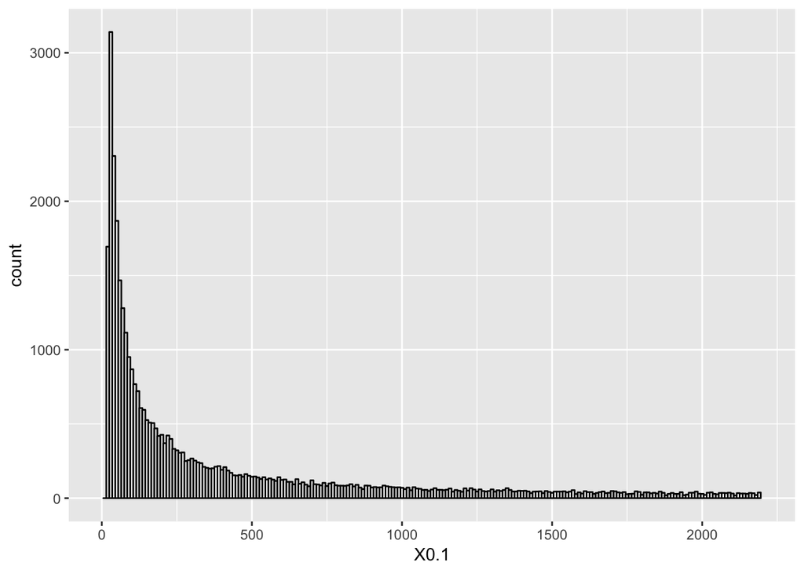

```r
n = 100000
m = 21

X0.1 <- VGAM::rpareto(n, m, 0.1)
X0.2 <- VGAM::rpareto(n, m, 0.2)
X0.3 <- VGAM::rpareto(n, m, 0.3)
X0.4 <- VGAM::rpareto(n, m, 0.4)
X0.5 <- VGAM::rpareto(n, m, 0.5)
X0.6 <- VGAM::rpareto(n, m, 0.6)
X0.7 <- VGAM::rpareto(n, m, 0.7)
X1.0 <- VGAM::rpareto(n, m, 1)

ggplot() + aes(X0.1) + geom_histogram(binwidth=10, colour="black", fill="white") + scale_x_continuous(limits=c(0,2200))
```

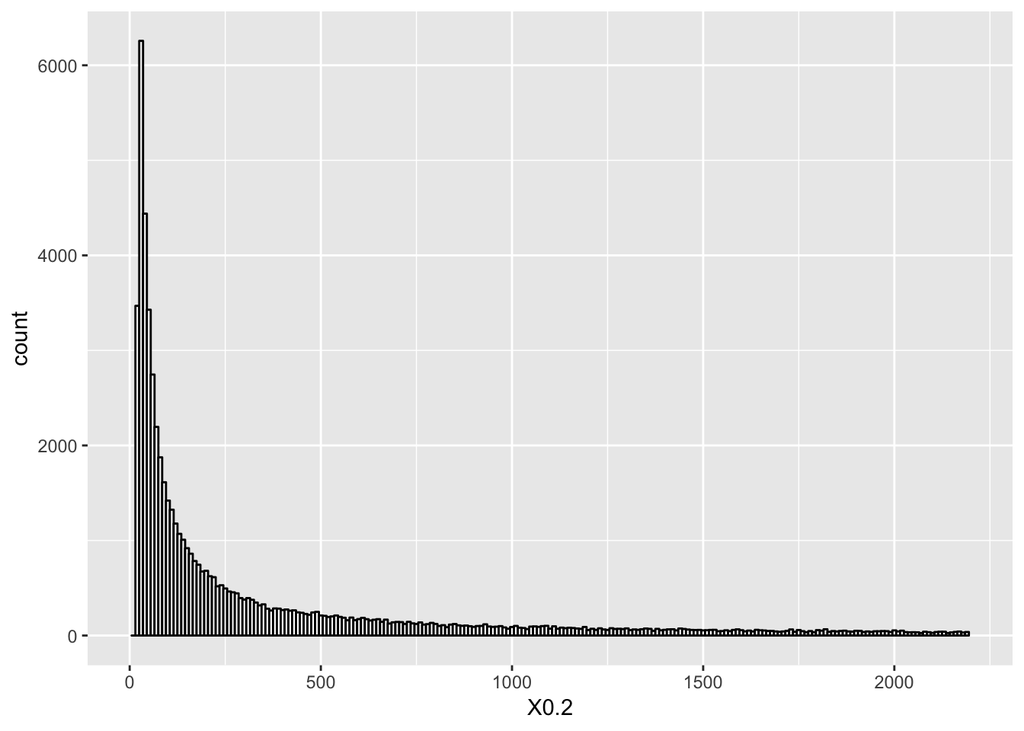

```r
ggplot() + aes(X0.2) + geom_histogram(binwidth=10, colour="black", fill="white") + scale_x_continuous(limits=c(0,2200))
```

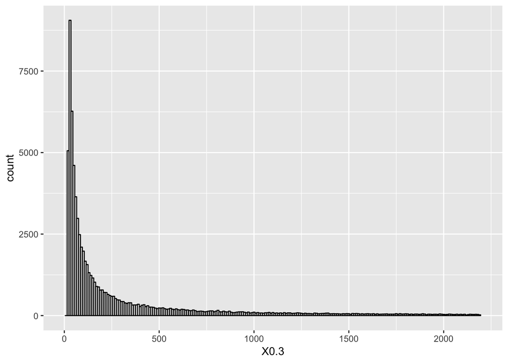

```r
ggplot() + aes(X0.3) + geom_histogram(binwidth=10, colour="black", fill="white") + scale_x_continuous(limits=c(0,2200))
```

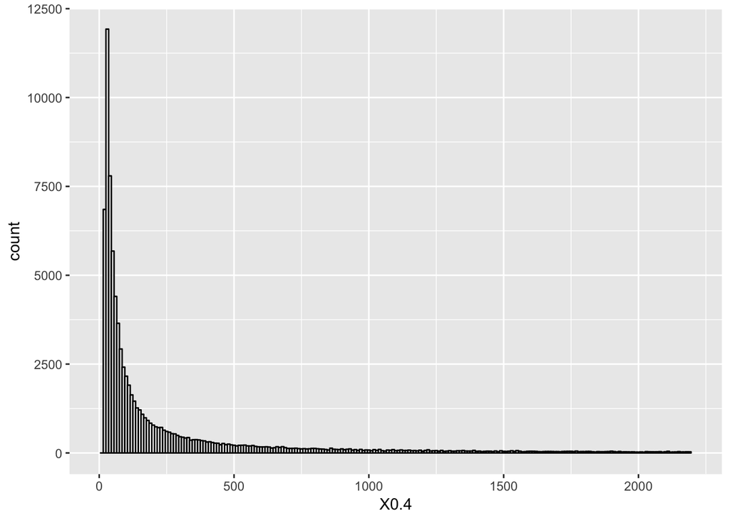

```r
ggplot() + aes(X0.4) + geom_histogram(binwidth=10, colour="black", fill="white") + scale_x_continuous(limits=c(0,2200))
```

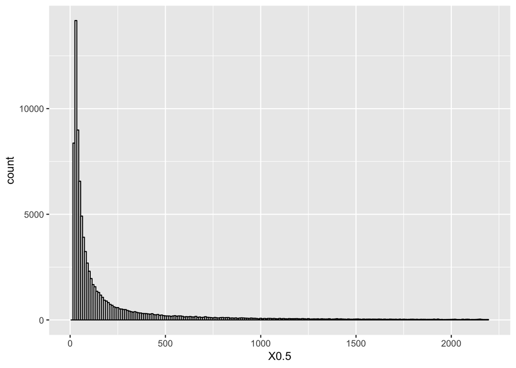

```r
ggplot() + aes(X0.5) + geom_histogram(binwidth=10, colour="black", fill="white") + scale_x_continuous(limits=c(0,2200))
```

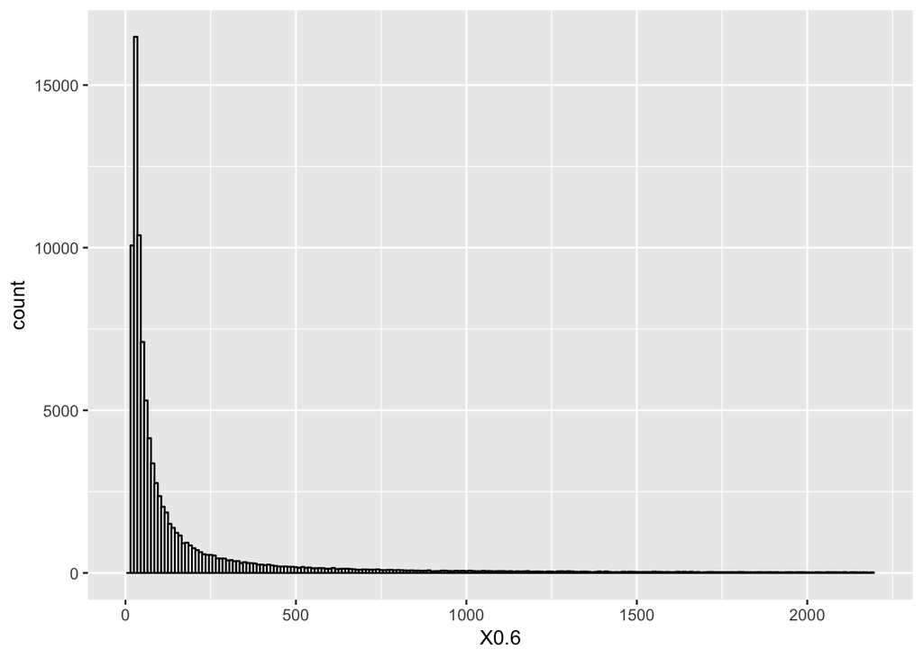

```r
ggplot() + aes(X0.6) + geom_histogram(binwidth=10, colour="black", fill="white") + scale_x_continuous(limits=c(0,2200))
```

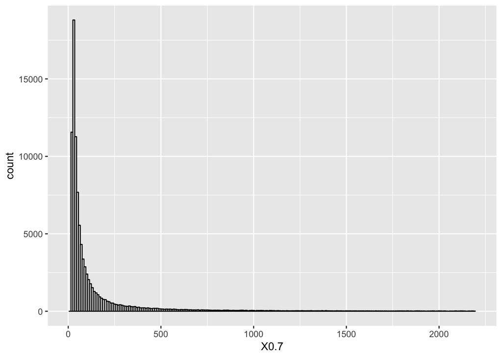

```r
ggplot() + aes(X0.7) + geom_histogram(binwidth=10, colour="black", fill="white") + scale_x_continuous(limits=c(0,2200))
```

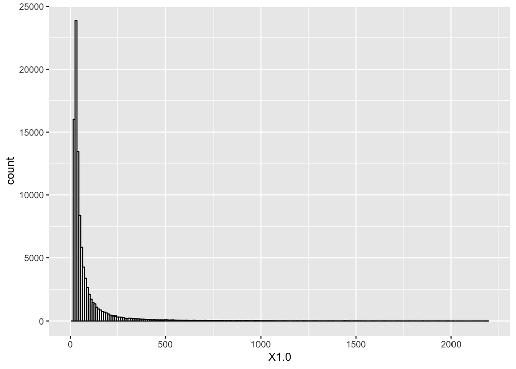

```r
ggplot() + aes(X1.0) + geom_histogram(binwidth=10, colour="black", fill="white") + scale_x_continuous(limits=c(0,2200))
```

Plus alpha est grand et moins les données sont dispersées. Si on compare avec la distribution de `Barre`, on peut en déduire que $\alpha$ doit se situer aux alentours de 0.3-0.6.

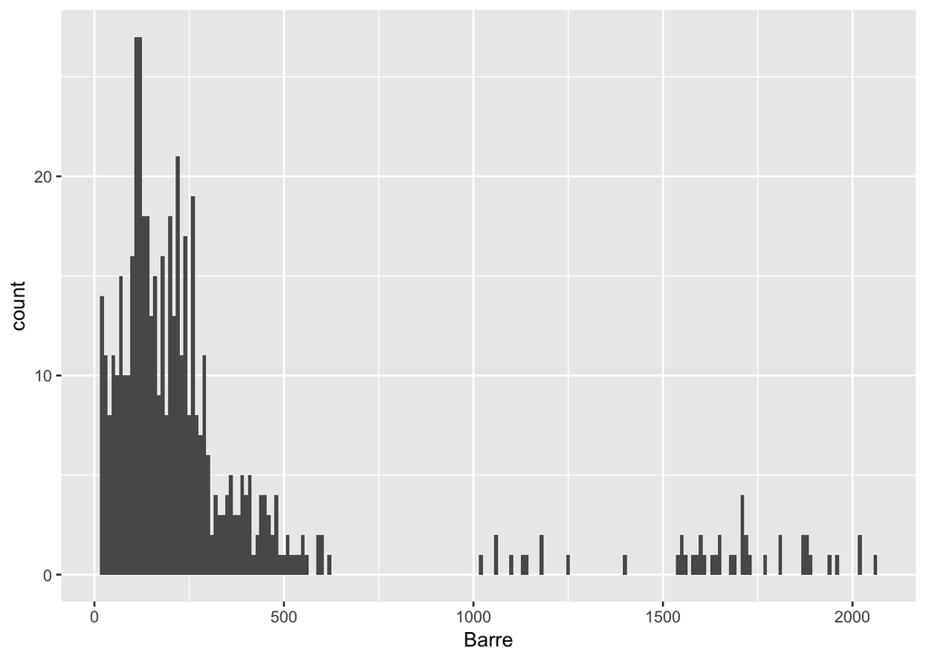

```r
Barre = mutations$Barre
ggplot() + aes(Barre) +
  geom_histogram(binwidth = 10)
```